# HomeWorkClear

## veri önümüze geldiğinde sırasıyla;

**1-) hocanın attığı verinin ekteki metaData'sını inceleriz**

**2-) GEREKLİ KÜTÜPHANELERİN İNSTALL VE İMPORT SAFHASI**

**3-) VERİYİ OKUTMA, İNCELEME VE YAPILACAKLAR SIRALAMASINA KARAR VERME SÜRECİ**

**4-) VERİDE NaN DEĞER KOTROLÜ VE AYIKLAMASI**

**5-) VERİNİN SON HALİNE YÜZEYSEL BİR BAKIŞ**

**6-) VERİDE SÜTUN SATIR KESİŞİMLERİNDEKİ DEĞERLERİ EKTEKİ AÇIKLAMA DOSYASINDA YAZAN DEĞERLERLE DEĞİŞTİRDİM**

(veriyi daha rahat analiz edbilmek adına sütun isimlerini yeniden adlandırırz)

**7-)VERİYİ İNCELEME, HATALI VEYA AYKIRI DEĞER BULMA VE DÜZELTME SAFHASI**

**8-)BINNING(KATAGORİZASYON) İŞLEMLERİ İLE VERİYE YENİ PARAMETRE SÜTUNLARI EKLEME**

**8-)VERİYİ İSTATİSTİKSEL İNCELEME, KORELASYON, GROUP BY İLE GRUPLAMA VE GÖRSELLEŞTİRME**

(çıkarımlarla ilerleyip veri madenciliği yaptığımız ve veriden veri çıkarttığımız en önemli yerdir)

**9-)KENDİ ANALİZLERİM DIŞINDA KÜTÜPHANE ANALİZLERİ 2 FARKLI ANALİZ DOSYASI ELDESİ (İLETTİĞİM DOSYADAKİ EKTEDİRLER)**

## 1-)GEREKLİ KÜTÜPHANELERİN İNSTALL VE İMPORT SAFHASI

```python
!pip install pandas
```

```python
!pip install numpy
```

```python
import pandas as pd
```

```python
import numpy as np   # boşlukları sılmek ve sütun isimleini tezilemek için
```

## 2-)VERİYİ OKUTMA, İNCELEME VE YAPILACAKLAR SIRALAMASINA KARAR VERME SÜRECİ

```python
df = pd.read_excel("odev.xlsx")  #exel dosyasını okuma
df                               #veriye bir bakalım
```

|  | HB010 | HB030 | HB031 | HB050 | HH010 | HH020 | HH030 | HH050 | HH060 | HH070 | ... | HE040 | HE050 | HE060 | HE070 | HE080 | HE090 | HE100 | HE110 | HE120 | HG110 |
| --- | --- | --- | --- | --- | --- | --- | --- | --- | --- | --- | --- | --- | --- | --- | --- | --- | --- | --- | --- | --- | --- |
| 0 | 2014 | TR1 | TR11 | 5 | 4 | 2 | 2011 | 14883333333333300 | 3 | 90 | ... | 6 | 7000 | 2 | 3 | 1 | 1 | 1 | 1 | 1 | 5.766760e+04 |
| 1 | 2014 | TR1 | TR11 | 5 | 4 | 2 | 2011 | 1565 | 4 | 120 | ... | 3 | 3000 | 1 | 2 | 1 | 1 | 1 | 1 | 2 | 3.739140e+04 |
| 2 | 2014 | TR1 | TR11 | 11 | 4 | 3 | 2011 | 675 | 4 | 120 | ... | 5 | 6000 | 3 | 2 | 1 | 1 | 1 | 1 | 1 | 9.336600e+04 |
| 3 | 2014 | TR1 | TR11 | 6 | 3 | 2 | 2013 | 7583333333333330 | 3 | 100 | ... | 5 | 4000 | 2 | 2 | 2 | 1 | 1 | 1 | 3 | 3.210000e+04 |
| 4 | 2014 | TR1 | TR11 | 6 | 4 | 1 | 2009 | 20277663294425100 | 3 | 70 | ... | 2 | 2000 | 2 | 1 | 2 | 1 | 1 | 1 | 3 | 3.271027e+16 |
| ... | ... | ... | ... | ... | ... | ... | ... | ... | ... | ... | ... | ... | ... | ... | ... | ... | ... | ... | ... | ... | ... |
| 22735 | 2014 | TRC | TRC3 | 13 | 1 | 1 | 2006 | 7833333333333330 | 3 | 100 | ... | 5 | 1500 | 3 | 2 | 2 | 1 | 1 | 2 | 3 | 2.959551e+16 |
| 22736 | 2014 | TRC | TRC3 | 13 | 1 | 1 | 1988 | 45 | 3 | 115 | ... | 4 | 800 | 2 | 2 | 2 | 2 | 1 | 2 | 3 | 2.286901e+16 |
| 22737 | 2014 | TRC | TRC3 | 13 | 1 | 1 | 1990 | 75 | 2 | 80 | ... | 2 | 1500 | 1 | 4 | 2 | 2 | 1 | 2 | 2 | 9.965104e+15 |
| 22738 | 2014 | TRC | TRC3 | 12 | 1 | 1 | 1990 | 75 | 3 | 120 | ... | 2 | 2000 | 2 | 4 | 2 | 2 | 1 | 2 | 2 | 1.525663e+16 |
| 22739 | 2014 | TRC | TRC3 | 13 | 1 | 4 | 2007 | 12833333333333300 | 2 | 60 | ... | 2 | 2500 | 2 | 4 | 2 | 1 | 1 | 1 | 2 | 1.656510e+16 |

22740 rows × 47 columns

```python
df.info()                        #veriye sütünsal bir bakış atalım
```

```
<class 'pandas.core.frame.DataFrame'>
RangeIndex: 22740 entries, 0 to 22739
Data columns (total 47 columns):
 #   Column  Non-Null Count  Dtype
---  ------  --------------  -----
 0   HB010   22740 non-null  int64
 1   HB030   22740 non-null  object
 2   HB031   22740 non-null  object
 3   HB050   22740 non-null  int64
 4   HH010   22740 non-null  int64
 5   HH020   22740 non-null  int64
 6   HH030   22740 non-null  int64
 7   HH050   22740 non-null  object
 8   HH060   22740 non-null  int64
 9   HH070   22740 non-null  int64
```

[output cut: 39 more lines]

```python
sütunlar = ["Anket Yılı", "1.Düzey Bölgelendirme", "2.Düzey Bölgelendirme", "Hane Halkı Tipi Kodu", "Oturulan Konut Tipi",
            "Konut Mülkiyet", "O Konutta Oturmaya veya sahip olmaya Başlanılan Yıl", "Aylık Ort.Konut Masrafı",
            "Konut Oda Sayısı", "Konut m^2", "Konut Isıtma Sistemi", "ısınmak içn en fazla kullanılan yakıt türü",
            "konutta banyo veya duşun var olma durumu", "konutta tuvaletin mevcut(ev içinde) olma durumu",
            "konutta bağımsız mutfağın mevcut olma durumu", "konutta borulu su sisteminin mevcut olma durumu",
            "konutta sıcak su sisteminin(güneş enerjisi,kombi,şofben,termal su) olma durumu",
            "hane halkının sabit telefon hattına sahip olma durumu", "hane halkının cep telfonuna sahip olma durumu",
            "hane halkının renkli TV ye sahip olma durumu", "hanehalkının PC ye sahip olma durumu",
            "hanehalkının internete sahip olma durumu(pc ye sahip olanlardan)", "hanehalkının çamaşır makinesi olma durumu",
            "Buzdolabı olma durumu", "bulaşık maknesi olma durumu", "klima olma durumu", "otomobil olma durumu(iş amaçlılar hariç)",
            "konutta rutubet olma durumu", "konutta izolasyon olma durumu", "konutta odaların yeterli ışık almama durumu",
            "Konutta komşulardan veya sokaktan gürültü probleminin olup olmadığı", "konutun kullanım alanının yeterli olup olmadığı",
            "yaşanılan çevrede hava kirliliği durumu", "suç ve şiddet olaylarının var olma durumu",
            "son12 ay içinde ev kirasının veya konut kredisinin planlandığı gibi ödenememe durumu",
            "son12 ay içinde elektrik,su,gaz faturalarının planlandığı gibi ödenememe durumu(borçla ödeme ödenmiş kabul edilecektir)",
            "son12 ay içinde taksit,kredi kartı ve diğer borç ödemelerinin planlandığı gibi gitmeme durumu",
            "hane aylık geliriyle Hane Gençinebilme Durumu", "Hanenin Geçinebilmek için min. ihtıyacı TL",
            "konut harcamalarının haneye getirdiği yük tipi", "Konut dışı borç ve taksit ödemelerinin haneye getirdiği yğk tipi",
            "hane 1 hafta tatil masrafını karşılayabilir mi", "hane 2 günde bir et yemeyi karşılayabilir mi",
            "hane beklenmedik mecburi 452TL haycamayı ödeyebilme durumu", "Hane ev ısınmasını ekonomik sağlayabiliyor mu",
            "2. el dahil, mobilyalarınız eskidiğinde yeniler misiniz", "Toplam Hane kullanılabilir geliri"]

df = pd.read_excel("odev.xlsx", names = sütunlar)  #kolonların ismini değiştirdik.  NOT: isim verirken "  isim " şeklinde ismin başına/sonuna
                                                   #boşluk bırakırsak daha aşşalarda sütunu çağırırken veya panipüle ederken sıkıntı yaşayabiliriz
                                                   #şayet sıkıntı yaşarsak df.columns = df.columns.str.strip() fonkunu kullanbiliriz
                                                   #aynı şekilde satırdaki varsa string türündeki verlerinde başta ve sondaki boşluklarını kaldrımalıyız
                                                   #veriye yeni kolonları ile birlikte bakalım
```

```python
 # df.columns = [süt.title() for süt in df.columns]   kısa yoldan sütunlardaki küçük baş harfleri büyüttük

yeni_sutun_isimleri = []                              #uzun yoldan yaptık

for i in df.columns:
    yeni_sutun_isimleri.append(i.title())

df.columns = yeni_sutun_isimleri
df.columns
```

```
Index(['Anket Yılı', '1.Düzey Bölgelendirme', '2.Düzey Bölgelendirme',
       'Hane Halkı Tipi Kodu', 'Oturulan Konut Tipi', 'Konut Mülkiyet',
       'O Konutta Oturmaya Veya Sahip Olmaya Başlanılan Yıl',
       'Aylık Ort.Konut Masrafı', 'Konut Oda Sayısı', 'Konut M^2',
       'Konut Isıtma Sistemi', 'Isınmak Içn En Fazla Kullanılan Yakıt Türü',
       'Konutta Banyo Veya Duşun Var Olma Durumu',
       'Konutta Tuvaletin Mevcut(Ev Içinde) Olma Durumu',
       'Konutta Bağımsız Mutfağın Mevcut Olma Durumu',
       'Konutta Borulu Su Sisteminin Mevcut Olma Durumu',
       'Konutta Sıcak Su Sisteminin(Güneş Enerjisi,Kombi,Şofben,Termal Su) Olma Durumu',
       'Hane Halkının Sabit Telefon Hattına Sahip Olma Durumu',
       'Hane Halkının Cep Telfonuna Sahip Olma Durumu',
       'Hane Halkının Renkli Tv Ye Sahip Olma Durumu',
       'Hanehalkının Pc Ye Sahip Olma Durumu',
       'Hanehalkının Internete Sahip Olma Durumu(Pc Ye Sahip Olanlardan)',
       'Hanehalkının Çamaşır Makinesi Olma Durumu', 'Buzdolabı Olma Durumu',
       'Bulaşık Maknesi Olma Durumu', 'Klima Olma Durumu',
       'Otomobil Olma Durumu(Iş Amaçlılar Hariç)',
       'Konutta Rutubet Olma Durumu', 'Konutta Izolasyon Olma Durumu',
       'Konutta Odaların Yeterli Işık Almama Durumu',
       'Konutta Komşulardan Veya Sokaktan Gürültü Probleminin Olup Olmadığı',
       'Konutun Kullanım Alanının Yeterli Olup Olmadığı',
       'Yaşanılan Çevrede Hava Kirliliği Durumu',
       'Suç Ve Şiddet Olaylarının Var Olma Durumu',
       'Son12 Ay Içinde Ev Kirasının Veya Konut Kredisinin Planlandığı Gibi Ödenememe Durumu',
       'Son12 Ay Içinde Elektrik,Su,Gaz Faturalarının Planlandığı Gibi Ödenememe Durumu(Borçla Ödeme Ödenmiş Kabul Edilecektir)',
       'Son12 Ay Içinde Taksit,Kredi Kartı Ve Diğer Borç Ödemelerinin Planlandığı Gibi Gitmeme Durumu',
       'Hane Aylık Geliriyle Hane Gençinebilme Durumu',
       'Hanenin Geçinebilmek Için Min. Ihtıyacı Tl',
       'Konut Harcamalarının Haneye Getirdiği Yük Tipi',
       'Konut Dışı Borç Ve Taksit Ödemelerinin Haneye Getirdiği Yğk Tipi',
       'Hane 1 Hafta Tatil Masrafını Karşılayabilir Mi',
       'Hane 2 Günde Bir Et Yemeyi Karşılayabilir Mi',
       'Hane Beklenmedik Mecburi 452Tl Haycamayı Ödeyebilme Durumu',
       'Hane Ev Isınmasını Ekonomik Sağlayabiliyor Mu',
       '2. El Dahil, Mobilyalarınız Eskidiğinde Yeniler Misiniz',
       'Toplam Hane Kullanılabilir Geliri'],
      dtype='object')
```

```python
df
```

|  | Anket Yılı | 1.Düzey Bölgelendirme | 2.Düzey Bölgelendirme | Hane Halkı Tipi Kodu | Oturulan Konut Tipi | Konut Mülkiyet | O Konutta Oturmaya Veya Sahip Olmaya Başlanılan Yıl | Aylık Ort.Konut Masrafı | Konut Oda Sayısı | Konut M^2 | ... | Hane Aylık Geliriyle Hane Gençinebilme Durumu | Hanenin Geçinebilmek Için Min. Ihtıyacı Tl | Konut Harcamalarının Haneye Getirdiği Yük Tipi | Konut Dışı Borç Ve Taksit Ödemelerinin Haneye Getirdiği Yğk Tipi | Hane 1 Hafta Tatil Masrafını Karşılayabilir Mi | Hane 2 Günde Bir Et Yemeyi Karşılayabilir Mi | Hane Beklenmedik Mecburi 452Tl Haycamayı Ödeyebilme Durumu | Hane Ev Isınmasını Ekonomik Sağlayabiliyor Mu | 2. El Dahil, Mobilyalarınız Eskidiğinde Yeniler Misiniz | Toplam Hane Kullanılabilir Geliri |
| --- | --- | --- | --- | --- | --- | --- | --- | --- | --- | --- | --- | --- | --- | --- | --- | --- | --- | --- | --- | --- | --- |
| 0 | 2014 | TR1 | TR11 | 5 | 4 | 2 | 2011 | 14883333333333300 | 3 | 90 | ... | 6 | 7000 | 2 | 3 | 1 | 1 | 1 | 1 | 1 | 5.766760e+04 |
| 1 | 2014 | TR1 | TR11 | 5 | 4 | 2 | 2011 | 1565 | 4 | 120 | ... | 3 | 3000 | 1 | 2 | 1 | 1 | 1 | 1 | 2 | 3.739140e+04 |
| 2 | 2014 | TR1 | TR11 | 11 | 4 | 3 | 2011 | 675 | 4 | 120 | ... | 5 | 6000 | 3 | 2 | 1 | 1 | 1 | 1 | 1 | 9.336600e+04 |
| 3 | 2014 | TR1 | TR11 | 6 | 3 | 2 | 2013 | 7583333333333330 | 3 | 100 | ... | 5 | 4000 | 2 | 2 | 2 | 1 | 1 | 1 | 3 | 3.210000e+04 |
| 4 | 2014 | TR1 | TR11 | 6 | 4 | 1 | 2009 | 20277663294425100 | 3 | 70 | ... | 2 | 2000 | 2 | 1 | 2 | 1 | 1 | 1 | 3 | 3.271027e+16 |
| ... | ... | ... | ... | ... | ... | ... | ... | ... | ... | ... | ... | ... | ... | ... | ... | ... | ... | ... | ... | ... | ... |
| 22735 | 2014 | TRC | TRC3 | 13 | 1 | 1 | 2006 | 7833333333333330 | 3 | 100 | ... | 5 | 1500 | 3 | 2 | 2 | 1 | 1 | 2 | 3 | 2.959551e+16 |
| 22736 | 2014 | TRC | TRC3 | 13 | 1 | 1 | 1988 | 45 | 3 | 115 | ... | 4 | 800 | 2 | 2 | 2 | 2 | 1 | 2 | 3 | 2.286901e+16 |
| 22737 | 2014 | TRC | TRC3 | 13 | 1 | 1 | 1990 | 75 | 2 | 80 | ... | 2 | 1500 | 1 | 4 | 2 | 2 | 1 | 2 | 2 | 9.965104e+15 |
| 22738 | 2014 | TRC | TRC3 | 12 | 1 | 1 | 1990 | 75 | 3 | 120 | ... | 2 | 2000 | 2 | 4 | 2 | 2 | 1 | 2 | 2 | 1.525663e+16 |
| 22739 | 2014 | TRC | TRC3 | 13 | 1 | 4 | 2007 | 12833333333333300 | 2 | 60 | ... | 2 | 2500 | 2 | 4 | 2 | 1 | 1 | 1 | 2 | 1.656510e+16 |

22740 rows × 47 columns

```python
df.describe()    #veriyi istatistiksel olara inceledik
```

|  | Anket Yılı | Hane Halkı Tipi Kodu | Oturulan Konut Tipi | Konut Mülkiyet | O Konutta Oturmaya Veya Sahip Olmaya Başlanılan Yıl | Konut Oda Sayısı | Konut M^2 | Konut Isıtma Sistemi | Isınmak Içn En Fazla Kullanılan Yakıt Türü | Konutta Banyo Veya Duşun Var Olma Durumu | ... | Hane Aylık Geliriyle Hane Gençinebilme Durumu | Hanenin Geçinebilmek Için Min. Ihtıyacı Tl | Konut Harcamalarının Haneye Getirdiği Yük Tipi | Konut Dışı Borç Ve Taksit Ödemelerinin Haneye Getirdiği Yğk Tipi | Hane 1 Hafta Tatil Masrafını Karşılayabilir Mi | Hane 2 Günde Bir Et Yemeyi Karşılayabilir Mi | Hane Beklenmedik Mecburi 452Tl Haycamayı Ödeyebilme Durumu | Hane Ev Isınmasını Ekonomik Sağlayabiliyor Mu | 2. El Dahil, Mobilyalarınız Eskidiğinde Yeniler Misiniz | Toplam Hane Kullanılabilir Geliri |
| --- | --- | --- | --- | --- | --- | --- | --- | --- | --- | --- | --- | --- | --- | --- | --- | --- | --- | --- | --- | --- | --- |
| count | 22740.0 | 22740.000000 | 22740.000000 | 22740.000000 | 22740.000000 | 22740.000000 | 22740.000000 | 22740.000000 | 22740.000000 | 22740.000000 | ... | 22740.000000 | 22740.000000 | 22740.000000 | 22740.000000 | 22740.000000 | 22740.000000 | 22740.000000 | 22740.000000 | 22740.000000 | 2.274000e+04 |
| mean | 2014.0 | 9.429420 | 2.326033 | 1.720185 | 1999.592964 | 3.462621 | 104.735664 | 1.728144 | 2.592040 | 1.081618 | ... | 2.778936 | 2638.944063 | 2.024362 | 2.585884 | 1.685796 | 1.344239 | 1.306069 | 1.159499 | 1.880827 | 1.039734e+16 |
| std | 0.0 | 2.729373 | 1.285232 | 1.085722 | 13.583863 | 0.854960 | 33.104601 | 0.952068 | 1.492352 | 0.372697 | ... | 1.131017 | 2571.305912 | 0.628021 | 1.184083 | 0.464208 | 0.475130 | 0.460869 | 0.366149 | 0.696881 | 1.227392e+16 |
| min | 2014.0 | 5.000000 | 1.000000 | 1.000000 | 1930.000000 | 1.000000 | 25.000000 | 1.000000 | 1.000000 | 1.000000 | ... | 1.000000 | 150.000000 | 1.000000 | 1.000000 | 1.000000 | 1.000000 | 1.000000 | 1.000000 | 1.000000 | 7.050000e+02 |
| 25% | 2014.0 | 7.000000 | 1.000000 | 1.000000 | 1993.000000 | 3.000000 | 85.000000 | 1.000000 | 2.000000 | 1.000000 | ... | 2.000000 | 1500.000000 | 2.000000 | 2.000000 | 1.000000 | 1.000000 | 1.000000 | 1.000000 | 1.000000 | 4.915000e+14 |
| 50% | 2014.0 | 10.000000 | 3.000000 | 1.000000 | 2004.000000 | 3.000000 | 100.000000 | 1.000000 | 2.000000 | 1.000000 | ... | 3.000000 | 2000.000000 | 2.000000 | 2.000000 | 2.000000 | 1.000000 | 1.000000 | 1.000000 | 2.000000 | 5.132628e+15 |
| 75% | 2014.0 | 12.000000 | 4.000000 | 2.000000 | 2011.000000 | 4.000000 | 120.000000 | 3.000000 | 3.000000 | 1.000000 | ... | 3.000000 | 3000.000000 | 2.000000 | 4.000000 | 2.000000 | 2.000000 | 2.000000 | 1.000000 | 2.000000 | 1.659591e+16 |
| max | 2014.0 | 16.000000 | 4.000000 | 4.000000 | 2014.000000 | 10.000000 | 700.000000 | 5.000000 | 8.000000 | 3.000000 | ... | 6.000000 | 250000.000000 | 3.000000 | 4.000000 | 2.000000 | 2.000000 | 2.000000 | 2.000000 | 3.000000 | 8.089293e+16 |

8 rows × 44 columns

```python
for i in df.columns:
    print(df[i].value_counts())
    print("---------------------------------------------")    #her kolondaki farklı değerlerden kaçar tane olduğuna baktık
                                                              #bu farklı değerler value_counts() ile gözükür ama biz sadece farklı değerlerin adlarına
                                                              #erişmek istiyorsak unique() fonkunu kullanabilirdik
```

```
Anket Yılı
2014    22740
Name: count, dtype: int64
---------------------------------------------
1.Düzey Bölgelendirme
TR3    3191
TR6    2771
TRC    2146
TR5    2104
TR8    2099
TR1    2015
TR4    2002
TR2    1518
TR7    1507
TRB    1420
TRA    1258
TR9     709
Name: count, dtype: int64
---------------------------------------------
2.Düzey Bölgelendirme
TR11    2015
TR51    1269
TR31    1175
TR41    1090
TR33    1057
TR62    1037
TR32     959
TR42     912
TR63     891
TR61     843
TR52     835
TR72     777
TR22     762
TR21     756
TRB1     745
TR83     737
TR71     730
TRC3     720
TRC1     719
TR91     709
```

[output cut: 313 more lines]

```
---------------------------------------------
Toplam Hane Kullanılabilir Geliri
1.200000e+04    32
1.800000e+04    29
1.440000e+04    19
1.500000e+04    17
2.400000e+04    17
                ..
2.222521e+15     1
1.523530e+16     1
1.749131e+15     1
9.342504e+15     1
1.656510e+16     1
Name: count, Length: 21628, dtype: int64
---------------------------------------------
```

```python
df.duplicated()   # birbirini tekrar eden satır var mı diye bakarız(kendinden öcekilere bakaraka T/F döndürür)
```

```
0        False
1        False
2        False
3        False
4        False
         ...
22735    False
22736    False
22737    False
22738    False
22739    False
Length: 22740, dtype: bool
```

```python
df[df.duplicated()]    #tekrar satır yokmuş. eğer olsaydı df.drop_duplicates(inplace=True) fonku ile o satırı silerdik
                                                                    #inplace=True olmasa verideki değişiklik kalıcı olmaz
```

|  | Anket Yılı | 1.Düzey Bölgelendirme | 2.Düzey Bölgelendirme | Hane Halkı Tipi Kodu | Oturulan Konut Tipi | Konut Mülkiyet | O Konutta Oturmaya Veya Sahip Olmaya Başlanılan Yıl | Aylık Ort.Konut Masrafı | Konut Oda Sayısı | Konut M^2 | ... | Hane Aylık Geliriyle Hane Gençinebilme Durumu | Hanenin Geçinebilmek Için Min. Ihtıyacı Tl | Konut Harcamalarının Haneye Getirdiği Yük Tipi | Konut Dışı Borç Ve Taksit Ödemelerinin Haneye Getirdiği Yğk Tipi | Hane 1 Hafta Tatil Masrafını Karşılayabilir Mi | Hane 2 Günde Bir Et Yemeyi Karşılayabilir Mi | Hane Beklenmedik Mecburi 452Tl Haycamayı Ödeyebilme Durumu | Hane Ev Isınmasını Ekonomik Sağlayabiliyor Mu | 2. El Dahil, Mobilyalarınız Eskidiğinde Yeniler Misiniz | Toplam Hane Kullanılabilir Geliri |
| --- | --- | --- | --- | --- | --- | --- | --- | --- | --- | --- | --- | --- | --- | --- | --- | --- | --- | --- | --- | --- | --- |

0 rows × 47 columns

```python
df["1.Düzey Bölgelendirme"] = df["1.Düzey Bölgelendirme"].str.strip()   #boşluk vardıysa bile artık yok hallettik
df["1.Düzey Bölgelendirme"].values
```

```
array(['TR1', 'TR1', 'TR1', ..., 'TRC', 'TRC', 'TRC'], dtype=object)
```

```python
df["2.Düzey Bölgelendirme"] = df["2.Düzey Bölgelendirme"].str.strip()   #diğer sütunu da hallettik
df["2.Düzey Bölgelendirme"].values
```

```
array(['TR11', 'TR11', 'TR11', ..., 'TRC3', 'TRC3', 'TRC3'], dtype=object)
```

## 3-)VERİDE NaN DEĞER KOTROLÜ VE AYIKLAMASI

```python
df.isnull()    # veride NaN değer kontrolü yaparız
```

|  | Anket Yılı | 1.Düzey Bölgelendirme | 2.Düzey Bölgelendirme | Hane Halkı Tipi Kodu | Oturulan Konut Tipi | Konut Mülkiyet | O Konutta Oturmaya Veya Sahip Olmaya Başlanılan Yıl | Aylık Ort.Konut Masrafı | Konut Oda Sayısı | Konut M^2 | ... | Hane Aylık Geliriyle Hane Gençinebilme Durumu | Hanenin Geçinebilmek Için Min. Ihtıyacı Tl | Konut Harcamalarının Haneye Getirdiği Yük Tipi | Konut Dışı Borç Ve Taksit Ödemelerinin Haneye Getirdiği Yğk Tipi | Hane 1 Hafta Tatil Masrafını Karşılayabilir Mi | Hane 2 Günde Bir Et Yemeyi Karşılayabilir Mi | Hane Beklenmedik Mecburi 452Tl Haycamayı Ödeyebilme Durumu | Hane Ev Isınmasını Ekonomik Sağlayabiliyor Mu | 2. El Dahil, Mobilyalarınız Eskidiğinde Yeniler Misiniz | Toplam Hane Kullanılabilir Geliri |
| --- | --- | --- | --- | --- | --- | --- | --- | --- | --- | --- | --- | --- | --- | --- | --- | --- | --- | --- | --- | --- | --- |
| 0 | False | False | False | False | False | False | False | False | False | False | ... | False | False | False | False | False | False | False | False | False | False |
| 1 | False | False | False | False | False | False | False | False | False | False | ... | False | False | False | False | False | False | False | False | False | False |
| 2 | False | False | False | False | False | False | False | False | False | False | ... | False | False | False | False | False | False | False | False | False | False |
| 3 | False | False | False | False | False | False | False | False | False | False | ... | False | False | False | False | False | False | False | False | False | False |
| 4 | False | False | False | False | False | False | False | False | False | False | ... | False | False | False | False | False | False | False | False | False | False |
| ... | ... | ... | ... | ... | ... | ... | ... | ... | ... | ... | ... | ... | ... | ... | ... | ... | ... | ... | ... | ... | ... |
| 22735 | False | False | False | False | False | False | False | False | False | False | ... | False | False | False | False | False | False | False | False | False | False |
| 22736 | False | False | False | False | False | False | False | False | False | False | ... | False | False | False | False | False | False | False | False | False | False |
| 22737 | False | False | False | False | False | False | False | False | False | False | ... | False | False | False | False | False | False | False | False | False | False |
| 22738 | False | False | False | False | False | False | False | False | False | False | ... | False | False | False | False | False | False | False | False | False | False |
| 22739 | False | False | False | False | False | False | False | False | False | False | ... | False | False | False | False | False | False | False | False | False | False |

22740 rows × 47 columns

```python
df.isnull().sum()  # hiçbir verimizde NaN değer yok
                   # olsaydı df.dropna(inplace=True) fonku ile NaN değerleri kalıcı olarak df bigDatasından silebilirdik
                   # veyahut istatistiksel yöntemlerle df.fillna() fonkunu kullanarak NaN değerleri doldurabilirdik
                   #parantez içine df.median() yazarsak NaN değerleri madian ile doldurur inplace:True unutma kalıcı değişiklik için
                   # df.mean() yazarsak NaN değerleri sütunun ortalama değeri ile doldurur
```

```
Anket Yılı                                                                                                                 0
1.Düzey Bölgelendirme                                                                                                      0
2.Düzey Bölgelendirme                                                                                                      0
Hane Halkı Tipi Kodu                                                                                                       0
Oturulan Konut Tipi                                                                                                        0
Konut Mülkiyet                                                                                                             0
O Konutta Oturmaya Veya Sahip Olmaya Başlanılan Yıl                                                                        0
Aylık Ort.Konut Masrafı                                                                                                    0
Konut Oda Sayısı                                                                                                           0
Konut M^2                                                                                                                  0
Konut Isıtma Sistemi                                                                                                       0
Isınmak Içn En Fazla Kullanılan Yakıt Türü                                                                                 0
Konutta Banyo Veya Duşun Var Olma Durumu                                                                                   0
Konutta Tuvaletin Mevcut(Ev Içinde) Olma Durumu                                                                            0
Konutta Bağımsız Mutfağın Mevcut Olma Durumu                                                                               0
Konutta Borulu Su Sisteminin Mevcut Olma Durumu                                                                            0
Konutta Sıcak Su Sisteminin(Güneş Enerjisi,Kombi,Şofben,Termal Su) Olma Durumu                                             0
Hane Halkının Sabit Telefon Hattına Sahip Olma Durumu                                                                      0
Hane Halkının Cep Telfonuna Sahip Olma Durumu                                                                              0
Hane Halkının Renkli Tv Ye Sahip Olma Durumu                                                                               0
Hanehalkının Pc Ye Sahip Olma Durumu                                                                                       0
Hanehalkının Internete Sahip Olma Durumu(Pc Ye Sahip Olanlardan)                                                           0
Hanehalkının Çamaşır Makinesi Olma Durumu                                                                                  0
Buzdolabı Olma Durumu                                                                                                      0
Bulaşık Maknesi Olma Durumu                                                                                                0
Klima Olma Durumu                                                                                                          0
Otomobil Olma Durumu(Iş Amaçlılar Hariç)                                                                                   0
Konutta Rutubet Olma Durumu                                                                                                0
Konutta Izolasyon Olma Durumu                                                                                              0
Konutta Odaların Yeterli Işık Almama Durumu                                                                                0
Konutta Komşulardan Veya Sokaktan Gürültü Probleminin Olup Olmadığı                                                        0
Konutun Kullanım Alanının Yeterli Olup Olmadığı                                                                            0
Yaşanılan Çevrede Hava Kirliliği Durumu                                                                                    0
Suç Ve Şiddet Olaylarının Var Olma Durumu                                                                                  0
Son12 Ay Içinde Ev Kirasının Veya Konut Kredisinin Planlandığı Gibi Ödenememe Durumu                                       0
Son12 Ay Içinde Elektrik,Su,Gaz Faturalarının Planlandığı Gibi Ödenememe Durumu(Borçla Ödeme Ödenmiş Kabul Edilecektir)    0
Son12 Ay Içinde Taksit,Kredi Kartı Ve Diğer Borç Ödemelerinin Planlandığı Gibi Gitmeme Durumu                              0
Hane Aylık Geliriyle Hane Gençinebilme Durumu                                                                              0
Hanenin Geçinebilmek Için Min. Ihtıyacı Tl                                                                                 0
Konut Harcamalarının Haneye Getirdiği Yük Tipi                                                                             0
Konut Dışı Borç Ve Taksit Ödemelerinin Haneye Getirdiği Yğk Tipi                                                           0
Hane 1 Hafta Tatil Masrafını Karşılayabilir Mi                                                                             0
Hane 2 Günde Bir Et Yemeyi Karşılayabilir Mi                                                                               0
Hane Beklenmedik Mecburi 452Tl Haycamayı Ödeyebilme Durumu                                                                 0
Hane Ev Isınmasını Ekonomik Sağlayabiliyor Mu                                                                              0
2. El Dahil, Mobilyalarınız Eskidiğinde Yeniler Misiniz                                                                    0
Toplam Hane Kullanılabilir Geliri                                                                                          0
dtype: int64
```

## 4-)VERİNİN SON HALİNE YÜZEYSEL BİR BAKIŞ

```python
df.head(1)
```

|  | Anket Yılı | 1.Düzey Bölgelendirme | 2.Düzey Bölgelendirme | Hane Halkı Tipi Kodu | Oturulan Konut Tipi | Konut Mülkiyet | O Konutta Oturmaya Veya Sahip Olmaya Başlanılan Yıl | Aylık Ort.Konut Masrafı | Konut Oda Sayısı | Konut M^2 | ... | Hane Aylık Geliriyle Hane Gençinebilme Durumu | Hanenin Geçinebilmek Için Min. Ihtıyacı Tl | Konut Harcamalarının Haneye Getirdiği Yük Tipi | Konut Dışı Borç Ve Taksit Ödemelerinin Haneye Getirdiği Yğk Tipi | Hane 1 Hafta Tatil Masrafını Karşılayabilir Mi | Hane 2 Günde Bir Et Yemeyi Karşılayabilir Mi | Hane Beklenmedik Mecburi 452Tl Haycamayı Ödeyebilme Durumu | Hane Ev Isınmasını Ekonomik Sağlayabiliyor Mu | 2. El Dahil, Mobilyalarınız Eskidiğinde Yeniler Misiniz | Toplam Hane Kullanılabilir Geliri |
| --- | --- | --- | --- | --- | --- | --- | --- | --- | --- | --- | --- | --- | --- | --- | --- | --- | --- | --- | --- | --- | --- |
| 0 | 2014 | TR1 | TR11 | 5 | 4 | 2 | 2011 | 14883333333333300 | 3 | 90 | ... | 6 | 7000 | 2 | 3 | 1 | 1 | 1 | 1 | 1 | 57667.6 |

1 rows × 47 columns

```python
df.tail(1)
```

|  | Anket Yılı | 1.Düzey Bölgelendirme | 2.Düzey Bölgelendirme | Hane Halkı Tipi Kodu | Oturulan Konut Tipi | Konut Mülkiyet | O Konutta Oturmaya Veya Sahip Olmaya Başlanılan Yıl | Aylık Ort.Konut Masrafı | Konut Oda Sayısı | Konut M^2 | ... | Hane Aylık Geliriyle Hane Gençinebilme Durumu | Hanenin Geçinebilmek Için Min. Ihtıyacı Tl | Konut Harcamalarının Haneye Getirdiği Yük Tipi | Konut Dışı Borç Ve Taksit Ödemelerinin Haneye Getirdiği Yğk Tipi | Hane 1 Hafta Tatil Masrafını Karşılayabilir Mi | Hane 2 Günde Bir Et Yemeyi Karşılayabilir Mi | Hane Beklenmedik Mecburi 452Tl Haycamayı Ödeyebilme Durumu | Hane Ev Isınmasını Ekonomik Sağlayabiliyor Mu | 2. El Dahil, Mobilyalarınız Eskidiğinde Yeniler Misiniz | Toplam Hane Kullanılabilir Geliri |
| --- | --- | --- | --- | --- | --- | --- | --- | --- | --- | --- | --- | --- | --- | --- | --- | --- | --- | --- | --- | --- | --- |
| 22739 | 2014 | TRC | TRC3 | 13 | 1 | 4 | 2007 | 12833333333333300 | 2 | 60 | ... | 2 | 2500 | 2 | 4 | 2 | 1 | 1 | 1 | 2 | 1.656510e+16 |

1 rows × 47 columns

```python
df.sample(1, random_state = 10)     # random değeri bi saıya eşitlersek ve bir alt satırda aynı fonku aynı sayıyla çağırırsak aynı değrer basılır
```

|  | Anket Yılı | 1.Düzey Bölgelendirme | 2.Düzey Bölgelendirme | Hane Halkı Tipi Kodu | Oturulan Konut Tipi | Konut Mülkiyet | O Konutta Oturmaya Veya Sahip Olmaya Başlanılan Yıl | Aylık Ort.Konut Masrafı | Konut Oda Sayısı | Konut M^2 | ... | Hane Aylık Geliriyle Hane Gençinebilme Durumu | Hanenin Geçinebilmek Için Min. Ihtıyacı Tl | Konut Harcamalarının Haneye Getirdiği Yük Tipi | Konut Dışı Borç Ve Taksit Ödemelerinin Haneye Getirdiği Yğk Tipi | Hane 1 Hafta Tatil Masrafını Karşılayabilir Mi | Hane 2 Günde Bir Et Yemeyi Karşılayabilir Mi | Hane Beklenmedik Mecburi 452Tl Haycamayı Ödeyebilme Durumu | Hane Ev Isınmasını Ekonomik Sağlayabiliyor Mu | 2. El Dahil, Mobilyalarınız Eskidiğinde Yeniler Misiniz | Toplam Hane Kullanılabilir Geliri |
| --- | --- | --- | --- | --- | --- | --- | --- | --- | --- | --- | --- | --- | --- | --- | --- | --- | --- | --- | --- | --- | --- |
| 20182 | 2014 | TRB | TRB2 | 13 | 1 | 1 | 1998 | 62.5 | 2 | 60 | ... | 1 | 2000 | 1 | 1 | 2 | 2 | 2 | 2 | 2 | 5.764998e+15 |

1 rows × 47 columns

## 5-)VERİDE SÜTUN SATIR KESİŞİMLERİNDEKİ DEĞERLERİ

## EKTEKİ AÇIKLAMA DOSYASINDA YAZAN DEĞERLERLE DEĞİŞTİRDİM

**(Map() Fonk. in Pandas Library)**

**Verileri, ekteki dosyasının açıklamaları direktifinde değiştirelim ve daha anlaşılır hale getirtelim = var olan sütunlardaki anlaması zor değerleri Map() fonku ve zözlüklerin kullanımı ile değştireceğim**

```python
df['1.Düzey Bölgelendirme'].value_counts()  #karmaşık olan sütun için yapalım (1. işlem)
```

```
1.Düzey Bölgelendirme
TR3    3191
TR6    2771
TRC    2146
TR5    2104
TR8    2099
TR1    2015
TR4    2002
TR2    1518
TR7    1507
TRB    1420
TRA    1258
TR9     709
Name: count, dtype: int64
```

```python
df['1.Düzey Bölgelendirme'].values   # parantez içinde başta ve sonda boşluk yok checking yapalım sıkıntı çıkmasın (1. işlem)
```

```
array(['TR1', 'TR1', 'TR1', ..., 'TRC', 'TRC', 'TRC'], dtype=object)
```

```python
Bölgelendirme1_dict = {      # sözlük kullandık (1.işlem)
    "TR1" : "İstanbul" ,
    "TR2" : "Batı Marmara" ,
    "TR3" : "Ege" ,
    "TR4" : "Doğu Marmara" ,
    "TR5" : "Batı Anadolu" ,
    "TR6" : "Akdeniz" ,
    "TR7" : "Orta Anadolu" ,
    "TR8" : "Batı Karadeniz" ,
    "TR9" : "Doğu Karadeniz" ,
    "TRA" : "Kuzey Doğu Anadolu" ,
    "TRB" : "Orta Doğu Anadolu" ,
    "TRC" : "Güney Doğu Anadolu"
}
```

```python
df['1.Düzey Bölgelendirme'] = df['1.Düzey Bölgelendirme'].map(Bölgelendirme1_dict)  #map fonku ile de sözlüktekilerle yer değiştirttik  (1. işlem)
df
```

|  | Anket Yılı | 1.Düzey Bölgelendirme | 2.Düzey Bölgelendirme | Hane Halkı Tipi Kodu | Oturulan Konut Tipi | Konut Mülkiyet | O Konutta Oturmaya Veya Sahip Olmaya Başlanılan Yıl | Aylık Ort.Konut Masrafı | Konut Oda Sayısı | Konut M^2 | ... | Hane Aylık Geliriyle Hane Gençinebilme Durumu | Hanenin Geçinebilmek Için Min. Ihtıyacı Tl | Konut Harcamalarının Haneye Getirdiği Yük Tipi | Konut Dışı Borç Ve Taksit Ödemelerinin Haneye Getirdiği Yğk Tipi | Hane 1 Hafta Tatil Masrafını Karşılayabilir Mi | Hane 2 Günde Bir Et Yemeyi Karşılayabilir Mi | Hane Beklenmedik Mecburi 452Tl Haycamayı Ödeyebilme Durumu | Hane Ev Isınmasını Ekonomik Sağlayabiliyor Mu | 2. El Dahil, Mobilyalarınız Eskidiğinde Yeniler Misiniz | Toplam Hane Kullanılabilir Geliri |
| --- | --- | --- | --- | --- | --- | --- | --- | --- | --- | --- | --- | --- | --- | --- | --- | --- | --- | --- | --- | --- | --- |
| 0 | 2014 | İstanbul | TR11 | 5 | 4 | 2 | 2011 | 14883333333333300 | 3 | 90 | ... | 6 | 7000 | 2 | 3 | 1 | 1 | 1 | 1 | 1 | 5.766760e+04 |
| 1 | 2014 | İstanbul | TR11 | 5 | 4 | 2 | 2011 | 1565 | 4 | 120 | ... | 3 | 3000 | 1 | 2 | 1 | 1 | 1 | 1 | 2 | 3.739140e+04 |
| 2 | 2014 | İstanbul | TR11 | 11 | 4 | 3 | 2011 | 675 | 4 | 120 | ... | 5 | 6000 | 3 | 2 | 1 | 1 | 1 | 1 | 1 | 9.336600e+04 |
| 3 | 2014 | İstanbul | TR11 | 6 | 3 | 2 | 2013 | 7583333333333330 | 3 | 100 | ... | 5 | 4000 | 2 | 2 | 2 | 1 | 1 | 1 | 3 | 3.210000e+04 |
| 4 | 2014 | İstanbul | TR11 | 6 | 4 | 1 | 2009 | 20277663294425100 | 3 | 70 | ... | 2 | 2000 | 2 | 1 | 2 | 1 | 1 | 1 | 3 | 3.271027e+16 |
| ... | ... | ... | ... | ... | ... | ... | ... | ... | ... | ... | ... | ... | ... | ... | ... | ... | ... | ... | ... | ... | ... |
| 22735 | 2014 | Güney Doğu Anadolu | TRC3 | 13 | 1 | 1 | 2006 | 7833333333333330 | 3 | 100 | ... | 5 | 1500 | 3 | 2 | 2 | 1 | 1 | 2 | 3 | 2.959551e+16 |
| 22736 | 2014 | Güney Doğu Anadolu | TRC3 | 13 | 1 | 1 | 1988 | 45 | 3 | 115 | ... | 4 | 800 | 2 | 2 | 2 | 2 | 1 | 2 | 3 | 2.286901e+16 |
| 22737 | 2014 | Güney Doğu Anadolu | TRC3 | 13 | 1 | 1 | 1990 | 75 | 2 | 80 | ... | 2 | 1500 | 1 | 4 | 2 | 2 | 1 | 2 | 2 | 9.965104e+15 |
| 22738 | 2014 | Güney Doğu Anadolu | TRC3 | 12 | 1 | 1 | 1990 | 75 | 3 | 120 | ... | 2 | 2000 | 2 | 4 | 2 | 2 | 1 | 2 | 2 | 1.525663e+16 |
| 22739 | 2014 | Güney Doğu Anadolu | TRC3 | 13 | 1 | 4 | 2007 | 12833333333333300 | 2 | 60 | ... | 2 | 2500 | 2 | 4 | 2 | 1 | 1 | 1 | 2 | 1.656510e+16 |

22740 rows × 47 columns

```python
df['2.Düzey Bölgelendirme'].value_counts()  #karmaşık olan bu sütun için yapalım  (2. işlem)
```

```
2.Düzey Bölgelendirme
TR11    2015
TR51    1269
TR31    1175
TR41    1090
TR33    1057
TR62    1037
TR32     959
TR42     912
TR63     891
TR61     843
TR52     835
TR72     777
TR22     762
TR21     756
TRB1     745
TR83     737
TR71     730
TRC3     720
TRC1     719
TR91     709
TRC2     707
TR81     686
TR82     676
TRB2     675
TRA1     641
TRA2     617
Name: count, dtype: int64
```

```python
df['2.Düzey Bölgelendirme'].values   # parantez içinde başta ve sonda boşluk yok checking yapalım sıkıntı çıkmasın (2. işlem)
```

```
array(['TR11', 'TR11', 'TR11', ..., 'TRC3', 'TRC3', 'TRC3'], dtype=object)
```

```python
Bölgelendirme2_dict2 = {     # dictionary kullandık (2. işlem)
    "TR11" : "İstanbul" ,
    "TR21" : "Tekirdağ, Edirne, Kırklareli" ,
    "TR22" : "Balıkesir, Çanakkale" ,
    "TR31" : "İzmir" ,
    "TR32" : "Aydın, Denizli, Muğla" ,
    "TR33" : "Manisa, Afyon, Kütahya, Uşak" ,
    "TR41" : "Bursa, Eskişehir, Bilecik" ,
    "TR42" : "Kocaeli, Sakarya, Düzce, Bolu, Yalova" ,
    "TR51" : "Ankara" ,
    "TR52" : "Konya, Karaman" ,
    "TR61" : "Antalya, Isparta, Burdur" ,
    "TR62" : "Adana, Mersin" ,
    "TR63" : "Hatay, Kahramanmaraş, Osmaniye" ,
    "TR71" : "Kırıkkale, Aksaray, Niğde, Nevşehir, Kırşehir" ,
    "TR72" : "Kayseri, Sivas, Yozgat" ,
    "TR81" : "Zonguldak, Karabük, Bartın" ,
    "TR82" : "Kastamonu, Çankırı, Sinop" ,
    "TR83" : "Samsun, Tokat, Çorum, Amasya" ,
    "TR90" : "Trabzon, Ordu, Giresun, Rize, Artvin, Gümüşhane" ,
    "TRA1" : "Erzurum, Erzincan, Bayburt" ,
    "TRA2" : "Ağrı, Kars, Iğdır, Ardahan" ,
    "TRB1" : "Malatya, Elazığ, Bingöl, Tunceli" ,
    "TRB2" : "Van, Muş, Bitlis, Hakkari" ,
    "TRC1" : "Gaziantep, Adıyaman, Kilis" ,
    "TRC2" : "Şanlıurfa, Diyarbakır" ,
    "TRC3" : "Mardin, Batman, Şırnak, Siirt"
}
```

```python
df['2.Düzey Bölgelendirme'] = df['2.Düzey Bölgelendirme'].map(Bölgelendirme2_dict2)  #map fonku ile de yer değiştirttik (2. işlem)
df
```

|  | Anket Yılı | 1.Düzey Bölgelendirme | 2.Düzey Bölgelendirme | Hane Halkı Tipi Kodu | Oturulan Konut Tipi | Konut Mülkiyet | O Konutta Oturmaya Veya Sahip Olmaya Başlanılan Yıl | Aylık Ort.Konut Masrafı | Konut Oda Sayısı | Konut M^2 | ... | Hane Aylık Geliriyle Hane Gençinebilme Durumu | Hanenin Geçinebilmek Için Min. Ihtıyacı Tl | Konut Harcamalarının Haneye Getirdiği Yük Tipi | Konut Dışı Borç Ve Taksit Ödemelerinin Haneye Getirdiği Yğk Tipi | Hane 1 Hafta Tatil Masrafını Karşılayabilir Mi | Hane 2 Günde Bir Et Yemeyi Karşılayabilir Mi | Hane Beklenmedik Mecburi 452Tl Haycamayı Ödeyebilme Durumu | Hane Ev Isınmasını Ekonomik Sağlayabiliyor Mu | 2. El Dahil, Mobilyalarınız Eskidiğinde Yeniler Misiniz | Toplam Hane Kullanılabilir Geliri |
| --- | --- | --- | --- | --- | --- | --- | --- | --- | --- | --- | --- | --- | --- | --- | --- | --- | --- | --- | --- | --- | --- |
| 0 | 2014 | İstanbul | İstanbul | 5 | 4 | 2 | 2011 | 14883333333333300 | 3 | 90 | ... | 6 | 7000 | 2 | 3 | 1 | 1 | 1 | 1 | 1 | 5.766760e+04 |
| 1 | 2014 | İstanbul | İstanbul | 5 | 4 | 2 | 2011 | 1565 | 4 | 120 | ... | 3 | 3000 | 1 | 2 | 1 | 1 | 1 | 1 | 2 | 3.739140e+04 |
| 2 | 2014 | İstanbul | İstanbul | 11 | 4 | 3 | 2011 | 675 | 4 | 120 | ... | 5 | 6000 | 3 | 2 | 1 | 1 | 1 | 1 | 1 | 9.336600e+04 |
| 3 | 2014 | İstanbul | İstanbul | 6 | 3 | 2 | 2013 | 7583333333333330 | 3 | 100 | ... | 5 | 4000 | 2 | 2 | 2 | 1 | 1 | 1 | 3 | 3.210000e+04 |
| 4 | 2014 | İstanbul | İstanbul | 6 | 4 | 1 | 2009 | 20277663294425100 | 3 | 70 | ... | 2 | 2000 | 2 | 1 | 2 | 1 | 1 | 1 | 3 | 3.271027e+16 |
| ... | ... | ... | ... | ... | ... | ... | ... | ... | ... | ... | ... | ... | ... | ... | ... | ... | ... | ... | ... | ... | ... |
| 22735 | 2014 | Güney Doğu Anadolu | Mardin, Batman, Şırnak, Siirt | 13 | 1 | 1 | 2006 | 7833333333333330 | 3 | 100 | ... | 5 | 1500 | 3 | 2 | 2 | 1 | 1 | 2 | 3 | 2.959551e+16 |
| 22736 | 2014 | Güney Doğu Anadolu | Mardin, Batman, Şırnak, Siirt | 13 | 1 | 1 | 1988 | 45 | 3 | 115 | ... | 4 | 800 | 2 | 2 | 2 | 2 | 1 | 2 | 3 | 2.286901e+16 |
| 22737 | 2014 | Güney Doğu Anadolu | Mardin, Batman, Şırnak, Siirt | 13 | 1 | 1 | 1990 | 75 | 2 | 80 | ... | 2 | 1500 | 1 | 4 | 2 | 2 | 1 | 2 | 2 | 9.965104e+15 |
| 22738 | 2014 | Güney Doğu Anadolu | Mardin, Batman, Şırnak, Siirt | 12 | 1 | 1 | 1990 | 75 | 3 | 120 | ... | 2 | 2000 | 2 | 4 | 2 | 2 | 1 | 2 | 2 | 1.525663e+16 |
| 22739 | 2014 | Güney Doğu Anadolu | Mardin, Batman, Şırnak, Siirt | 13 | 1 | 4 | 2007 | 12833333333333300 | 2 | 60 | ... | 2 | 2500 | 2 | 4 | 2 | 1 | 1 | 1 | 2 | 1.656510e+16 |

22740 rows × 47 columns

```python
df['Hane Halkı Tipi Kodu'].value_counts()  #(3. işlem)
```

```
Hane Halkı Tipi Kodu
13    4033
11    3322
10    3049
6     3047
12    2456
8     2404
5     2073
7     1820
9      529
16       7
Name: count, dtype: int64
```

**hane halkı tipi kodunun olduğu sütundaki bazı değerler bilinemiyordu açıklama dosyasından yola çıkarak**

**hocaya danışıldı, bu gbi durumlarda yapabileceğimiz 3 olasılık göz önüne geliyor**

**1-)var olup katagorizasyonu bilinmeyenleri bilinmmeyen olarak döndürme(ben bunu tercih ettim çünkü ne kadr çok veri o kadar analiz sonucu kesinlik)**

**2-)var olup katagorizasyonu bilinmeyenlerin bulunduğu satırları komple silmek(veri setimizi küçültür)**

**3-)katagorizasyon yapıp aşşada olduğu gibi mapping yapmadan önce katagorizasyonu bulunamayan hane halkı kodlarını boşaltıp yerlerine katagoizasyonu bilinenlerin ortalaması ile doldururuz yada ratgele bilinen bir kod atarız(uzun işlem)**

```python
# Integer to string mapping dictionary    (3. işlem)
int_to_str_dict = {
    5: "Tek kişilik hanehalkı",
    6: "Bağımlı çocuk olmayan iki yetişkinli yetişkinlerin ikisi de 65 yaşın altında",
    7: "Bağımlı çocuk olmayan iki yetişkinli yetişkinlerden en az biri 65 ve daha fazla yaşta",
    8: "Bağımlı çocuk olmayan diğer hanehalkı",
    9: "bilinmiyor",
    10: "bilinmiyor",
    11: "Bağımlı çocuk olmayan hanehalkları 6+7+8",
    12: "bilinmiyor",
    13: "bilinmiyor",
    16: "bilinmiyor"
}

# Integer array
int_array = [5, 6, 7, 8, 9, 10, 11, 12, 13, 16]

# String karşılıklarını değiştirelim
string_array = [int_to_str_dict.get(num) for num in int_array]

print(string_array)
```

[output not shown]

```python
df['Hane Halkı Tipi Kodu'].values   # parantez içinde başta ve sonda boşluk yok checking yapalım sıkıntı çıkmasın (3. işlem)
```

```
array([ 5,  5, 11, ..., 13, 12, 13], dtype=int64)
```

```python
df['Hane Halkı Tipi Kodu'] = df['Hane Halkı Tipi Kodu'].map(int_to_str_dict)  #map fonku ile de yer değiştirttik (3. işlem)
```

```python
df['Hane Halkı Tipi Kodu']   #(3. işlem)
```

```
0                                    Tek kişilik hanehalkı
1                                    Tek kişilik hanehalkı
2                 Bağımlı çocuk olmayan hanehalkları 6+7+8
3        Bağımlı çocuk olmayan iki yetişkinli yetişkinl...
4        Bağımlı çocuk olmayan iki yetişkinli yetişkinl...
                               ...
22735                                           bilinmiyor
22736                                           bilinmiyor
22737                                           bilinmiyor
22738                                           bilinmiyor
22739                                           bilinmiyor
Name: Hane Halkı Tipi Kodu, Length: 22740, dtype: object
```

```python
# Integer to string mapping dictionary    (4. işlem)
int_to_str_dict2 = {
    1: "Müstakil Konut",
    2: "İkiz ya da Sıralı Ev",
    3: "Apartman (10 daireden az)",
    4: "Apartman (10 daireden fazla)",
    5: "Diğer"
}

# Integer array
int_array2 = [1, 2, 3, 4, 5]

# String karşılıklarını değiştirelim
string_array2 = [int_to_str_dict2.get(num) for num in int_array2]

print(string_array2)
```

```
['Müstakil Konut', 'İkiz ya da Sıralı Ev', 'Apartman (10 daireden az)', 'Apartman (10 daireden fazla)', 'Diğer']
```

```python
df['Oturulan Konut Tipi'] = df['Oturulan Konut Tipi'].map(int_to_str_dict2) #(4. işlem)
```

```python
df['Oturulan Konut Tipi']   #(4. işlem)
```

```
0        Apartman (10 daireden fazla)
1        Apartman (10 daireden fazla)
2        Apartman (10 daireden fazla)
3           Apartman (10 daireden az)
4        Apartman (10 daireden fazla)
                     ...
22735                  Müstakil Konut
22736                  Müstakil Konut
22737                  Müstakil Konut
22738                  Müstakil Konut
22739                  Müstakil Konut
Name: Oturulan Konut Tipi, Length: 22740, dtype: object
```

```python
# Integer to string mapping dictionary    (5. işlem)
int_to_str_dict3 = {
    1: "Ev Sahibi",
    2: "Kiracı",
    3: "Lojman",
    4: "Diğer(herhangi bir kira ödemeyen)"
}

# Integer array
int_array3 = [1, 2, 3, 4]

# String karşılıklarını değiştirelim
string_array3 = [int_to_str_dict3.get(num) for num in int_array3]

print(string_array3)
```

```
['Ev Sahibi', 'Kiracı', 'Lojman', 'Diğer(herhangi bir kira ödemeyen)']
```

```python
df['Konut Mülkiyet'] = df['Konut Mülkiyet'].map(int_to_str_dict3) #(5. işlem)
```

```python
# Integer to string mapping dictionary    (6. işlem)
int_to_str_dict4 = {
    1: "Soba(kömür, gaz, doğalgaz, elektrik, vb.",
    2: "Kalorifer",
    3: "Kombi",
    4: "Klima",
    5: "Diğer"
}

# Integer array
int_array4 = [1, 2, 3, 4, 5]

# String karşılıklarını değiştirelim
string_array4 = [int_to_str_dict4.get(num) for num in int_array4]

print(string_array4)
```

```
['Soba(kömür, gaz, doğalgaz, elektrik, vb.', 'Kalorifer', 'Kombi', 'Klima', 'Diğer']
```

```python
df['Konut Isıtma Sistemi'] = df['Konut Isıtma Sistemi'].map(int_to_str_dict4) #(6. işlem)
```

```python
# Integer to string mapping dictionary    (7. işlem)
int_to_str_dict5 = {
    1: "Odun",
    2: "Kömür",
    3: "Doğalgaz",
    4: "Fuel-Oil",
    5: "LPG(tüpgaz)",
    6: "Elektrik",
    7: "Tezek",
    8: "Diğer"
}

# Integer array
int_array5 = [1, 2, 3, 4, 5, 6, 7, 8]

# String karşılıklarını değiştirelim
string_array5 = [int_to_str_dict5.get(num) for num in int_array5]

print(string_array5)
```

```
['Odun', 'Kömür', 'Doğalgaz', 'Fuel-Oil', 'LPG(tüpgaz)', 'Elektrik', 'Tezek', 'Diğer']
```

```python
df['Isınmak Içn En Fazla Kullanılan Yakıt Türü'] = df['Isınmak Içn En Fazla Kullanılan Yakıt Türü'].map(int_to_str_dict5) #(7. işlem)
```

```python
# Integer to string mapping dictionary    (8. işlem)
int_to_str_dict6 = {
    1: "Evet(sadece kendi kllanımında)",
    2: "Evet(paylaşılan)",
    3: "Hayır"
}

# Integer array
int_array6 = [1, 2, 3]

# String karşılıklarını değiştirelim
string_array6 = [int_to_str_dict6.get(num) for num in int_array6]

print(string_array6)
```

```
['Evet(sadece kendi kllanımında)', 'Evet(paylaşılan)', 'Hayır']
```

```python
df['Konutta Banyo Veya Duşun Var Olma Durumu'] = df['Konutta Banyo Veya Duşun Var Olma Durumu'].map(int_to_str_dict6) #(8. işlem)
```

```python
# Integer to string mapping dictionary    (9. işlem)
int_to_str_dict7 = {
    1: "Evet(sadece kendi kllanımında)",
    2: "Evet(paylaşılan)",
    3: "Hayır"
}

# Integer array
int_array7 = [1, 2, 3]

# String karşılıklarını değiştirelim
string_array7 = [int_to_str_dict7.get(num) for num in int_array7]

print(string_array7)
```

```
['Evet(sadece kendi kllanımında)', 'Evet(paylaşılan)', 'Hayır']
```

```python
df['Konutta Tuvaletin Mevcut(Ev Içinde) Olma Durumu'] = df['Konutta Tuvaletin Mevcut(Ev Içinde) Olma Durumu'].map(int_to_str_dict7) #(9. işlem)
```

```python
# Integer to string mapping dictionary    (10. işlem)
int_to_str_dict8 = {
    1: "Evet",
    2: "Hayır"
}

# Integer array
int_array8 = [1, 2]

# String karşılıklarını değiştirelim
string_array8 = [int_to_str_dict8.get(num) for num in int_array8]

print(string_array8)
```

```
['Evet', 'Hayır']
```

```python
df['Konutta Bağımsız Mutfağın Mevcut Olma Durumu'] = df['Konutta Bağımsız Mutfağın Mevcut Olma Durumu'].map(int_to_str_dict8) #(10. işlem)
```

```python
df['Konutta Borulu Su Sisteminin Mevcut Olma Durumu'] = df['Konutta Borulu Su Sisteminin Mevcut Olma Durumu'].map(int_to_str_dict8) #(11. işlem)
```

```python
df['Konutta Sıcak Su Sisteminin(Güneş Enerjisi,Kombi,Şofben,Termal Su) Olma Durumu'] = df['Konutta Sıcak Su Sisteminin(Güneş Enerjisi,Kombi,Şofben,Termal Su) Olma Durumu'].map(int_to_str_dict8) #(12. işlem)
```

```python
# Integer to string mapping dictionary    (13. işlem)
int_to_str_dict9 = {
    1: "Evet",
    2: "Hayır, maddi yetersizlik",
    3: "Hyır, diğer nedenler"
}

# Integer array
int_array9 = [1, 2, 3]

# String karşılıklarını değiştirelim
string_array9 = [int_to_str_dict9.get(num) for num in int_array9]

print(string_array9)
```

```
['Evet', 'Hayır, maddi yetersizlik', 'Hyır, diğer nedenler']
```

```python
df['Hane Halkının Sabit Telefon Hattına Sahip Olma Durumu'] = df['Hane Halkının Sabit Telefon Hattına Sahip Olma Durumu'].map(int_to_str_dict9) #(13. işlem)
```

```python
df['Hane Halkının Cep Telfonuna Sahip Olma Durumu'] = df['Hane Halkının Cep Telfonuna Sahip Olma Durumu'].map(int_to_str_dict9) #(14. işlem)
```

```python
df['Hane Halkının Renkli Tv Ye Sahip Olma Durumu'] = df['Hane Halkının Renkli Tv Ye Sahip Olma Durumu'].map(int_to_str_dict9) #(15. işlem)
```

```python
df['Hanehalkının Pc Ye Sahip Olma Durumu'] = df['Hanehalkının Pc Ye Sahip Olma Durumu'].map(int_to_str_dict9) #(16. işlem)
```

```python
df['Hanehalkının Internete Sahip Olma Durumu(Pc Ye Sahip Olanlardan)'] = df['Hanehalkının Internete Sahip Olma Durumu(Pc Ye Sahip Olanlardan)'].map(int_to_str_dict9) #(17. işlem)
```

```python
df['Hanehalkının Çamaşır Makinesi Olma Durumu'] = df['Hanehalkının Çamaşır Makinesi Olma Durumu'].map(int_to_str_dict9) #(18. işlem)
```

```python
df['Buzdolabı Olma Durumu'] = df['Buzdolabı Olma Durumu'].map(int_to_str_dict9) #(19. işlem)
```

```python
df['Bulaşık Maknesi Olma Durumu'] = df['Bulaşık Maknesi Olma Durumu'].map(int_to_str_dict9) #(20. işlem)
```

```python
df['Klima Olma Durumu'] = df['Klima Olma Durumu'].map(int_to_str_dict9) #(21. işlem)
```

```python
df['Otomobil Olma Durumu(Iş Amaçlılar Hariç)'] = df['Otomobil Olma Durumu(Iş Amaçlılar Hariç)'].map(int_to_str_dict9) #(22. işlem)
```

```python
for i in df.columns:
    print(df[i].value_counts())
    print("---------------------------------------------")
```

```
Anket Yılı
2014    22740
Name: count, dtype: int64
---------------------------------------------
1.Düzey Bölgelendirme
Ege                   3191
Akdeniz               2771
Güney Doğu Anadolu    2146
Batı Anadolu          2104
Batı Karadeniz        2099
İstanbul              2015
Doğu Marmara          2002
Batı Marmara          1518
Orta Anadolu          1507
Orta Doğu Anadolu     1420
Kuzey Doğu Anadolu    1258
Doğu Karadeniz         709
Name: count, dtype: int64
---------------------------------------------
2.Düzey Bölgelendirme
İstanbul                                         2015
Ankara                                           1269
İzmir                                            1175
Bursa, Eskişehir, Bilecik                        1090
Manisa, Afyon, Kütahya, Uşak                     1057
Adana, Mersin                                    1037
Aydın, Denizli, Muğla                             959
Kocaeli, Sakarya, Düzce, Bolu, Yalova             912
Hatay, Kahramanmaraş, Osmaniye                    891
Antalya, Isparta, Burdur                          843
Konya, Karaman                                    835
Kayseri, Sivas, Yozgat                            777
Balıkesir, Çanakkale                              762
Tekirdağ, Edirne, Kırklareli                      756
Malatya, Elazığ, Bingöl, Tunceli                  745
Samsun, Tokat, Çorum, Amasya                      737
Kırıkkale, Aksaray, Niğde, Nevşehir, Kırşehir     730
Mardin, Batman, Şırnak, Siirt                     720
Gaziantep, Adıyaman, Kilis                        719
Şanlıurfa, Diyarbakır                             707
```

[output cut: 308 more lines]

```
---------------------------------------------
Toplam Hane Kullanılabilir Geliri
1.200000e+04    32
1.800000e+04    29
1.440000e+04    19
1.500000e+04    17
2.400000e+04    17
                ..
2.222521e+15     1
1.523530e+16     1
1.749131e+15     1
9.342504e+15     1
1.656510e+16     1
Name: count, Length: 21628, dtype: int64
---------------------------------------------
```

```python
# Integer to string mapping dictionary    (23. işlem)
int_to_str_dict10 = {
    1: "Evet",
    2: "Hayır"
}

# Integer array
int_array10= [1, 2]

# String karşılıklarını değiştirelim
string_array10 = [int_to_str_dict10.get(num) for num in int_array10]

print(string_array10)
```

```
['Evet', 'Hayır']
```

```python
df['Konutta Rutubet Olma Durumu'] = df['Konutta Rutubet Olma Durumu'].map(int_to_str_dict10) #(23. işlem)
```

```python
df['Konutta Izolasyon Olma Durumu'] = df['Konutta Izolasyon Olma Durumu'].map(int_to_str_dict10) #(24. işlem)
```

```python
df['Konutta Odaların Yeterli Işık Almama Durumu'] = df['Konutta Odaların Yeterli Işık Almama Durumu'].map(int_to_str_dict10) #(25. işlem)
```

```python
df['Konutta Komşulardan Veya Sokaktan Gürültü Probleminin Olup Olmadığı'] = df['Konutta Komşulardan Veya Sokaktan Gürültü Probleminin Olup Olmadığı'].map(int_to_str_dict10) #(26. işlem)
```

```python
df['Konutun Kullanım Alanının Yeterli Olup Olmadığı'] = df['Konutun Kullanım Alanının Yeterli Olup Olmadığı'].map(int_to_str_dict10) #(27. işlem)
```

```python
df['Yaşanılan Çevrede Hava Kirliliği Durumu'] = df['Yaşanılan Çevrede Hava Kirliliği Durumu'].map(int_to_str_dict10) #(28. işlem)
```

```python
df['Suç Ve Şiddet Olaylarının Var Olma Durumu'] = df['Suç Ve Şiddet Olaylarının Var Olma Durumu'].map(int_to_str_dict10) #(29. işlem)
```

```python
df['Hane 1 Hafta Tatil Masrafını Karşılayabilir Mi'] = df['Hane 1 Hafta Tatil Masrafını Karşılayabilir Mi'].map(int_to_str_dict10) #(30. işlem)
```

```python
df['Hane 2 Günde Bir Et Yemeyi Karşılayabilir Mi'] = df['Hane 2 Günde Bir Et Yemeyi Karşılayabilir Mi'].map(int_to_str_dict10) #(31. işlem)
```

```python
df['Hane Beklenmedik Mecburi 452Tl Haycamayı Ödeyebilme Durumu'] = df['Hane Beklenmedik Mecburi 452Tl Haycamayı Ödeyebilme Durumu'].map(int_to_str_dict10) #(32. işlem)
```

```python
df['Hane Ev Isınmasını Ekonomik Sağlayabiliyor Mu'] = df['Hane Ev Isınmasını Ekonomik Sağlayabiliyor Mu'].map(int_to_str_dict10) #(33. işlem)
```

```python
# Integer to string mapping dictionary    (34. işlem)
int_to_str_dict11 = {
    1: "Evet(bir kez)",
    2: "Evet(2 veya daha fazla)",
    3: "Hayır Olmadı",
    4: "Bu Tür Ödeme Yok"
}

# Integer array
int_array11= [1, 2, 3, 4]

# String karşılıklarını değiştirelim
string_array11 = [int_to_str_dict11.get(num) for num in int_array11]

print(string_array11)
```

```
['Evet(bir kez)', 'Evet(2 veya daha fazla)', 'Hayır Olmadı', 'Bu Tür Ödeme Yok']
```

```python
df['Son12 Ay Içinde Ev Kirasının Veya Konut Kredisinin Planlandığı Gibi Ödenememe Durumu'] = df['Son12 Ay Içinde Ev Kirasının Veya Konut Kredisinin Planlandığı Gibi Ödenememe Durumu'].map(int_to_str_dict11) #(34. işlem)
```

```python
df['Son12 Ay Içinde Elektrik,Su,Gaz Faturalarının Planlandığı Gibi Ödenememe Durumu(Borçla Ödeme Ödenmiş Kabul Edilecektir)'] = df['Son12 Ay Içinde Elektrik,Su,Gaz Faturalarının Planlandığı Gibi Ödenememe Durumu(Borçla Ödeme Ödenmiş Kabul Edilecektir)'].map(int_to_str_dict11) #(35. işlem)
```

```python
df['Son12 Ay Içinde Taksit,Kredi Kartı Ve Diğer Borç Ödemelerinin Planlandığı Gibi Gitmeme Durumu'] = df['Son12 Ay Içinde Taksit,Kredi Kartı Ve Diğer Borç Ödemelerinin Planlandığı Gibi Gitmeme Durumu'].map(int_to_str_dict11) #(36. işlem)
```

```python
# Integer to string mapping dictionary    (37. işlem)
int_to_str_dict12 = {
    1: "Çok Zor",
    2: "Zor",
    3: "Biraz Zor",
    4: "Biraz Kolay",
    5: "Kolay",
    6: "Çok Kolay"
}

# Integer array
int_array12= [1, 2, 3, 4, 5, 6]

# String karşılıklarını değiştirelim
string_array12 = [int_to_str_dict12.get(num) for num in int_array12]

print(string_array12)
```

```
['Çok Zor', 'Zor', 'Biraz Zor', 'Biraz Kolay', 'Kolay', 'Çok Kolay']
```

```python
df['Hane Aylık Geliriyle Hane Gençinebilme Durumu'] = df['Hane Aylık Geliriyle Hane Gençinebilme Durumu'].map(int_to_str_dict12) #(37. işlem)
```

```python
# Integer to string mapping dictionary    (38. işlem)
int_to_str_dict13 = {
    1: "Çok Yük Getiriyor",
    2: "Biraz Yük Getiriyor",
    3: "Yük getirmiyor",
    4: "Taksit veya Borç Ödemesi Yok"
}

# Integer array
int_array13= [1, 2, 3, 4]

# String karşılıklarını değiştirelim
string_array13 = [int_to_str_dict13.get(num) for num in int_array13]

print(string_array13)
```

```
['Çok Yük Getiriyor', 'Biraz Yük Getiriyor', 'Yük getirmiyor', 'Taksit veya Borç Ödemesi Yok']
```

```python
df['Konut Harcamalarının Haneye Getirdiği Yük Tipi'] = df['Konut Harcamalarının Haneye Getirdiği Yük Tipi'].map(int_to_str_dict13) #(38. işlem)
```

```python
df['Konut Dışı Borç Ve Taksit Ödemelerinin Haneye Getirdiği Yğk Tipi'] = df['Konut Dışı Borç Ve Taksit Ödemelerinin Haneye Getirdiği Yğk Tipi'].map(int_to_str_dict13) #(39. işlem)
```

```python
df['2. El Dahil, Mobilyalarınız Eskidiğinde Yeniler Misiniz'] = df['2. El Dahil, Mobilyalarınız Eskidiğinde Yeniler Misiniz'].map(int_to_str_dict9) #(40. işlem)
```

```python
df  # yeni hali ile bakış atıyoruz veriye
```

|  | Anket Yılı | 1.Düzey Bölgelendirme | 2.Düzey Bölgelendirme | Hane Halkı Tipi Kodu | Oturulan Konut Tipi | Konut Mülkiyet | O Konutta Oturmaya Veya Sahip Olmaya Başlanılan Yıl | Aylık Ort.Konut Masrafı | Konut Oda Sayısı | Konut M^2 | ... | Hane Aylık Geliriyle Hane Gençinebilme Durumu | Hanenin Geçinebilmek Için Min. Ihtıyacı Tl | Konut Harcamalarının Haneye Getirdiği Yük Tipi | Konut Dışı Borç Ve Taksit Ödemelerinin Haneye Getirdiği Yğk Tipi | Hane 1 Hafta Tatil Masrafını Karşılayabilir Mi | Hane 2 Günde Bir Et Yemeyi Karşılayabilir Mi | Hane Beklenmedik Mecburi 452Tl Haycamayı Ödeyebilme Durumu | Hane Ev Isınmasını Ekonomik Sağlayabiliyor Mu | 2. El Dahil, Mobilyalarınız Eskidiğinde Yeniler Misiniz | Toplam Hane Kullanılabilir Geliri |
| --- | --- | --- | --- | --- | --- | --- | --- | --- | --- | --- | --- | --- | --- | --- | --- | --- | --- | --- | --- | --- | --- |
| 0 | 2014 | İstanbul | İstanbul | Tek kişilik hanehalkı | Apartman (10 daireden fazla) | Kiracı | 2011 | 14883333333333300 | 3 | 90 | ... | Çok Kolay | 7000 | Biraz Yük Getiriyor | Yük getirmiyor | Evet | Evet | Evet | Evet | Evet | 5.766760e+04 |
| 1 | 2014 | İstanbul | İstanbul | Tek kişilik hanehalkı | Apartman (10 daireden fazla) | Kiracı | 2011 | 1565 | 4 | 120 | ... | Biraz Zor | 3000 | Çok Yük Getiriyor | Biraz Yük Getiriyor | Evet | Evet | Evet | Evet | Hayır, maddi yetersizlik | 3.739140e+04 |
| 2 | 2014 | İstanbul | İstanbul | Bağımlı çocuk olmayan hanehalkları 6+7+8 | Apartman (10 daireden fazla) | Lojman | 2011 | 675 | 4 | 120 | ... | Kolay | 6000 | Yük getirmiyor | Biraz Yük Getiriyor | Evet | Evet | Evet | Evet | Evet | 9.336600e+04 |
| 3 | 2014 | İstanbul | İstanbul | Bağımlı çocuk olmayan iki yetişkinli yetişkinl... | Apartman (10 daireden az) | Kiracı | 2013 | 7583333333333330 | 3 | 100 | ... | Kolay | 4000 | Biraz Yük Getiriyor | Biraz Yük Getiriyor | Hayır | Evet | Evet | Evet | Hyır, diğer nedenler | 3.210000e+04 |
| 4 | 2014 | İstanbul | İstanbul | Bağımlı çocuk olmayan iki yetişkinli yetişkinl... | Apartman (10 daireden fazla) | Ev Sahibi | 2009 | 20277663294425100 | 3 | 70 | ... | Zor | 2000 | Biraz Yük Getiriyor | Çok Yük Getiriyor | Hayır | Evet | Evet | Evet | Hyır, diğer nedenler | 3.271027e+16 |
| ... | ... | ... | ... | ... | ... | ... | ... | ... | ... | ... | ... | ... | ... | ... | ... | ... | ... | ... | ... | ... | ... |
| 22735 | 2014 | Güney Doğu Anadolu | Mardin, Batman, Şırnak, Siirt | bilinmiyor | Müstakil Konut | Ev Sahibi | 2006 | 7833333333333330 | 3 | 100 | ... | Kolay | 1500 | Yük getirmiyor | Biraz Yük Getiriyor | Hayır | Evet | Evet | Hayır | Hyır, diğer nedenler | 2.959551e+16 |
| 22736 | 2014 | Güney Doğu Anadolu | Mardin, Batman, Şırnak, Siirt | bilinmiyor | Müstakil Konut | Ev Sahibi | 1988 | 45 | 3 | 115 | ... | Biraz Kolay | 800 | Biraz Yük Getiriyor | Biraz Yük Getiriyor | Hayır | Hayır | Evet | Hayır | Hyır, diğer nedenler | 2.286901e+16 |
| 22737 | 2014 | Güney Doğu Anadolu | Mardin, Batman, Şırnak, Siirt | bilinmiyor | Müstakil Konut | Ev Sahibi | 1990 | 75 | 2 | 80 | ... | Zor | 1500 | Çok Yük Getiriyor | Taksit veya Borç Ödemesi Yok | Hayır | Hayır | Evet | Hayır | Hayır, maddi yetersizlik | 9.965104e+15 |
| 22738 | 2014 | Güney Doğu Anadolu | Mardin, Batman, Şırnak, Siirt | bilinmiyor | Müstakil Konut | Ev Sahibi | 1990 | 75 | 3 | 120 | ... | Zor | 2000 | Biraz Yük Getiriyor | Taksit veya Borç Ödemesi Yok | Hayır | Hayır | Evet | Hayır | Hayır, maddi yetersizlik | 1.525663e+16 |
| 22739 | 2014 | Güney Doğu Anadolu | Mardin, Batman, Şırnak, Siirt | bilinmiyor | Müstakil Konut | Diğer(herhangi bir kira ödemeyen) | 2007 | 12833333333333300 | 2 | 60 | ... | Zor | 2500 | Biraz Yük Getiriyor | Taksit veya Borç Ödemesi Yok | Hayır | Evet | Evet | Evet | Hayır, maddi yetersizlik | 1.656510e+16 |

22740 rows × 47 columns

```python
for i in df.columns:
    print(df[i].value_counts())
    print("---------------------------------------------")    #her kolondaki farklı değerlerden kaçar tane olduğuna baktık
                                                              #bu farklı değerler value_counts() ile gözükür ama biz sadece farklı değerlerin adlarına
                                                              #erişmek istiyorsak unique() fonkunu kullanabilirdik
```

```
Anket Yılı
2014    22740
Name: count, dtype: int64
---------------------------------------------
1.Düzey Bölgelendirme
Ege                   3191
Akdeniz               2771
Güney Doğu Anadolu    2146
Batı Anadolu          2104
Batı Karadeniz        2099
İstanbul              2015
Doğu Marmara          2002
Batı Marmara          1518
Orta Anadolu          1507
Orta Doğu Anadolu     1420
Kuzey Doğu Anadolu    1258
Doğu Karadeniz         709
Name: count, dtype: int64
---------------------------------------------
2.Düzey Bölgelendirme
İstanbul                                         2015
Ankara                                           1269
İzmir                                            1175
Bursa, Eskişehir, Bilecik                        1090
Manisa, Afyon, Kütahya, Uşak                     1057
Adana, Mersin                                    1037
Aydın, Denizli, Muğla                             959
Kocaeli, Sakarya, Düzce, Bolu, Yalova             912
Hatay, Kahramanmaraş, Osmaniye                    891
Antalya, Isparta, Burdur                          843
Konya, Karaman                                    835
Kayseri, Sivas, Yozgat                            777
Balıkesir, Çanakkale                              762
Tekirdağ, Edirne, Kırklareli                      756
Malatya, Elazığ, Bingöl, Tunceli                  745
Samsun, Tokat, Çorum, Amasya                      737
Kırıkkale, Aksaray, Niğde, Nevşehir, Kırşehir     730
Mardin, Batman, Şırnak, Siirt                     720
Gaziantep, Adıyaman, Kilis                        719
Şanlıurfa, Diyarbakır                             707
```

[output cut: 308 more lines]

```
---------------------------------------------
Toplam Hane Kullanılabilir Geliri
1.200000e+04    32
1.800000e+04    29
1.440000e+04    19
1.500000e+04    17
2.400000e+04    17
                ..
2.222521e+15     1
1.523530e+16     1
1.749131e+15     1
9.342504e+15     1
1.656510e+16     1
Name: count, Length: 21628, dtype: int64
---------------------------------------------
```

## 6-)VERİYİ İNCELEME, HATALI VEYA AYKIRI DEĞER BULMA VE DÜZELTME SAFHASI

verileri en son hali ile incelediğimizde düzeltmemiz gereken 2 sütunun var daha durduğunu anlıyoruz bunlar:

**Aylık Ort.Konut Masrafı --> içinde outlier veriler var <-- Toplam Hane Kullanılabilir Geliri**

**Veride OutLier Veri Varsa Yapabilinecek İşlemler :**

**1-)** Outlier değerleri temizlemek için çeşitli yöntemler kullanabiliriz. **Genellikle en yaygın kullanılan yöntemler z-skoru veya IQR (Interquartile Range) yöntemidir.** bu iki yöntem veride aşırı yüksek veya aşırı düşük verileri bulur daha sonra o değerler NaN yapılır sonrada o NaN lar ortalamalar ile doldurulur

**2-)** **Normalizasyon** yaparak değerleri istenilen aralığa indirgeyebiliriz. Çünkü görüyoruz çok büyük var. İndirgeme için log dönüşümü de kullanabiliriz **Log dönüşümü** sonucunda, büyük değerlerin ölçeği küçültülmüş olur. Bu dönüşüm, verinin dağılımını sıkıştırarak aşırı büyük değerleri daha anlaşılabilir hale getirir. Artık bu dönüştürülmüş veriyi kullanarak aykırı değerleri daha doğru bir şekilde tespit etmek daha kolayca mümkün olabilir.

**<<<<<<<<<<<<<<<<<<<<<<<<<<<<<<<<<<<<<<<<<<<<<<<<<<<<<<<<<<<<<<<<<**

**1-2 işlemlerinin birlikte kullanım sırası :**

**-----------------------------------------------**

**a-) Veriyi sayısal olarak yükleyin, eğer sayılar arasında boşlık karakteri varsa bu karakterleri kaldırın.**

**b-) obje veya string türlerde veri varsa sayısal türlere çevirin.**

**c-) Normalizasyon ile Logaritmik Dönüşüm Uygulama, Verilerin ölçeğini küçültmek için logaritmik dönüşüm (örneğin, np.log10) uygulayın.**

**d-) Aykırı Değerleri Tespit Etme, Z-skoru veya IQR yöntemleriyle aykırı değerleri belirleyin**

**e-) Aykırı değerlere NaN atayın.**

**f-) NaN değerleri NaN değer olmayan verilerin ort. ile değiştirin**

**g-) Son değrleri yazdırın ve gözlemsel kontrol yapın**

**>>>>>>>>>>>>>>>>>>>>>>>>>>>>>>>>>>>>>>>>>>>>>>>>>>>>>>>>>>>>>>>>>>>**

**f-) işleminde NaN'ları ort ile doldurduk**

**Regresyon** yaparak da doldurabilirdim mesela : Apply() ile bir sonraki adınlarda tanımlayacağım -ev konforu- def fonsiyonunun çıktılarını kullanarak doğrusal regresyon yaparak Aylık Ort.Konut Masrafı sütunundaki istenmeyen OutLier değerlerin(NaN'ların) değerlerini belirleyebilirdim

**Regresyon Nedir? Kısaca**

Regresyon, bir değişkenin (bağımlı değişken) diğer bir veya daha fazla değişkenle (bağımsız değişkenler) ilişkisini modellemek için kullanılan bir istatistiksel analiz yöntemidir. Temel amacı, bağımlı değişkenin değerini tahmin etmek veya açıklamaktır. En yaygın regresyon türlerinden biri doğrusal regresyondur. Bu türde, bağımsız değişkenlerin doğrusal bir fonksiyonunu kullanarak bağımlı değişkenin tahmin edilmesi sağlanır. Örneğin, bir evin fiyatını tahmin etmek için evin büyüklüğü (metrekare), oda sayısı gibi faktörler kullanılabilir. regresyon analizinde kullanılan ana hedef, bağımsız değişkenlerin bağımlı değişken üzerindeki etkisini anlamak ve bu etkiye dayalı tahminler yapmaktır.

**Regresyon Türleri:**

**-->Doğrusal Regresyon (Linear Regression): Bağımlı değişken ile bağımsız değişkenler arasındaki doğrusal ilişkiyi modellemek için kullanılır.**

**-->Çoklu Doğrusal Regresyon (Multiple Linear Regression): Birden fazla bağımsız değişkenin etkisini dikkate alır.**

**-->Lojistik Regresyon (Logistic Regression): Bağımlı değişkenin kategorik olduğu (örneğin, evet/hayır) durumlar için kullanılır.**

**-->Polinom Regresyon (Polynomial Regression): Bağımlı ve bağımsız değişkenler arasındaki ilişki doğrusal olmayıp, polinom bir denklemle modellenir.**

**------------------------------------------------------------------------**

**2 tane olan istenmeyen veri içeren sütun vardı**

**Şimdi onlara işlemler uygulayacağım, yukarıda bahsedilen metodlar göz önünde bulundurlacaktır.** **Eğer hala veriyi istenilen değerlerle dolu hale getiremezsem o istenmeyen değerler içeren iki sütunu silerek veri analizime devam edeceğim**

--> df = df.drop(['Toplam Hane Kullanılabilir Geliri'], axis=1)  
--> df = df.drop(['Aylık Ort.Konut Masrafı'], axis=1)

**-------------------------------------------------------------------------**

```python
!pip install pandas
!pip install numpy
```

```python
import pandas as pd
import numpy as np
```

**VERİNİN EN SON HALİNİ EXCEL FORMATINDA KAYDETTİM HAM_DOSYA ADINDA BURDAN SONRA ONUNLA İŞLEME DEVAM EDİCEM**

```python
df = pd.read_excel("ham_dosya.xlsx")  #satır ve sütünları kolayca yorumlanabilen yeni excel dosyasını okuttuk
```

```python
df
```

|  | Anket Yılı | 1.Düzey Bölgelendirme | 2.Düzey Bölgelendirme | Hane Halkı Tipi Kodu | Oturulan Konut Tipi | Konut Mülkiyet | O Konutta Oturmaya Veya Sahip Olmaya Başlanılan Yıl | Aylık Ort.Konut Masrafı | Konut Oda Sayısı | Konut M^2 | ... | Hane Aylık Geliriyle Hane Gençinebilme Durumu | Hanenin Geçinebilmek Için Min. Ihtıyacı Tl | Konut Harcamalarının Haneye Getirdiği Yük Tipi | Konut Dışı Borç Ve Taksit Ödemelerinin Haneye Getirdiği Yğk Tipi | Hane 1 Hafta Tatil Masrafını Karşılayabilir Mi | Hane 2 Günde Bir Et Yemeyi Karşılayabilir Mi | Hane Beklenmedik Mecburi 452Tl Haycamayı Ödeyebilme Durumu | Hane Ev Isınmasını Ekonomik Sağlayabiliyor Mu | 2. El Dahil, Mobilyalarınız Eskidiğinde Yeniler Misiniz | Toplam Hane Kullanılabilir Geliri |
| --- | --- | --- | --- | --- | --- | --- | --- | --- | --- | --- | --- | --- | --- | --- | --- | --- | --- | --- | --- | --- | --- |
| 0 | 2014 | İstanbul | İstanbul | Tek kişilik hanehalkı | Apartman (10 daireden fazla) | Kiracı | 2011 | 14883333333333300 | 3 | 90 | ... | Çok Kolay | 7000 | Biraz Yük Getiriyor | Yük getirmiyor | Evet | Evet | Evet | Evet | Evet | 5.766760e+04 |
| 1 | 2014 | İstanbul | İstanbul | Tek kişilik hanehalkı | Apartman (10 daireden fazla) | Kiracı | 2011 | 1565 | 4 | 120 | ... | Biraz Zor | 3000 | Çok Yük Getiriyor | Biraz Yük Getiriyor | Evet | Evet | Evet | Evet | Hayır, maddi yetersizlik | 3.739140e+04 |
| 2 | 2014 | İstanbul | İstanbul | Bağımlı çocuk olmayan hanehalkları 6+7+8 | Apartman (10 daireden fazla) | Lojman | 2011 | 675 | 4 | 120 | ... | Kolay | 6000 | Yük getirmiyor | Biraz Yük Getiriyor | Evet | Evet | Evet | Evet | Evet | 9.336600e+04 |
| 3 | 2014 | İstanbul | İstanbul | Bağımlı çocuk olmayan iki yetişkinli yetişkinl... | Apartman (10 daireden az) | Kiracı | 2013 | 7583333333333330 | 3 | 100 | ... | Kolay | 4000 | Biraz Yük Getiriyor | Biraz Yük Getiriyor | Hayır | Evet | Evet | Evet | Hyır, diğer nedenler | 3.210000e+04 |
| 4 | 2014 | İstanbul | İstanbul | Bağımlı çocuk olmayan iki yetişkinli yetişkinl... | Apartman (10 daireden fazla) | Ev Sahibi | 2009 | 20277663294425100 | 3 | 70 | ... | Zor | 2000 | Biraz Yük Getiriyor | Çok Yük Getiriyor | Hayır | Evet | Evet | Evet | Hyır, diğer nedenler | 3.271027e+16 |
| ... | ... | ... | ... | ... | ... | ... | ... | ... | ... | ... | ... | ... | ... | ... | ... | ... | ... | ... | ... | ... | ... |
| 22735 | 2014 | Güney Doğu Anadolu | Mardin, Batman, Şırnak, Siirt | bilinmiyor | Müstakil Konut | Ev Sahibi | 2006 | 7833333333333330 | 3 | 100 | ... | Kolay | 1500 | Yük getirmiyor | Biraz Yük Getiriyor | Hayır | Evet | Evet | Hayır | Hyır, diğer nedenler | 2.959551e+16 |
| 22736 | 2014 | Güney Doğu Anadolu | Mardin, Batman, Şırnak, Siirt | bilinmiyor | Müstakil Konut | Ev Sahibi | 1988 | 45 | 3 | 115 | ... | Biraz Kolay | 800 | Biraz Yük Getiriyor | Biraz Yük Getiriyor | Hayır | Hayır | Evet | Hayır | Hyır, diğer nedenler | 2.286901e+16 |
| 22737 | 2014 | Güney Doğu Anadolu | Mardin, Batman, Şırnak, Siirt | bilinmiyor | Müstakil Konut | Ev Sahibi | 1990 | 75 | 2 | 80 | ... | Zor | 1500 | Çok Yük Getiriyor | Taksit veya Borç Ödemesi Yok | Hayır | Hayır | Evet | Hayır | Hayır, maddi yetersizlik | 9.965104e+15 |
| 22738 | 2014 | Güney Doğu Anadolu | Mardin, Batman, Şırnak, Siirt | bilinmiyor | Müstakil Konut | Ev Sahibi | 1990 | 75 | 3 | 120 | ... | Zor | 2000 | Biraz Yük Getiriyor | Taksit veya Borç Ödemesi Yok | Hayır | Hayır | Evet | Hayır | Hayır, maddi yetersizlik | 1.525663e+16 |
| 22739 | 2014 | Güney Doğu Anadolu | Mardin, Batman, Şırnak, Siirt | bilinmiyor | Müstakil Konut | Diğer(herhangi bir kira ödemeyen) | 2007 | 12833333333333300 | 2 | 60 | ... | Zor | 2500 | Biraz Yük Getiriyor | Taksit veya Borç Ödemesi Yok | Hayır | Evet | Evet | Evet | Hayır, maddi yetersizlik | 1.656510e+16 |

22740 rows × 47 columns

## İstenmeyen Değerler İçeren Sütun_1 = Toplam Hane Kullanılabilir Geliri

**ÇÖZÜM YÖNTEMİ =**

**Verideki Çok Büyük Sayıları max 200.000 olacak şekilde Sınırladım**

**Veri içeriğinin türünü kontrol ettim sayı türlerinde veriler lazım bize ona göre dönüşüm yapmalıyız**

**ORTALAMADAN BÜYÜK DEĞERLERİ NAN YAPIP SORADA NANLARA NaN olmayan değerlerin ORTALAMASINI ATICAM**

```python
import matplotlib.pyplot as plt
import seaborn as sns
```

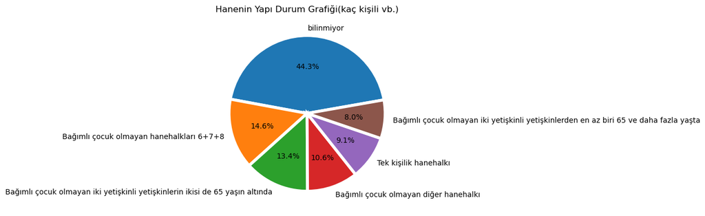

```python
df["Hane Halkı Tipi Kodu"].value_counts().plot.pie(
    autopct='%1.1f%%',  # Her bir dilimin yüzdesini gösterir
    wedgeprops={'linewidth': 4, 'edgecolor': 'white'},  # Dilimler arasında boşluk bırakır
    startangle=10  # Grafiği 90 derece döndürerek başlatır (isteğe bağlı)
)
plt.ylabel('')  # Y-eksenindeki etiketi kaldırır
plt.title("Hanenin Yapı Durum Grafiği(kaç kişili vb.)")
plt.show()
```

```python
df['Toplam Hane Kullanılabilir Geliri'].describe()     # hane aylık gelrinde Min 705 Tl gibi, gerçek olmayacak kadr az gelirler var.
                                                       # birey çalışmıyor olablir ama ailenin geçinmesi için en az birinin çalışması gerekli
                                                       # anketteki hane tipi grafiğini yukarıda incelediğimizde ankette öğreni yok yani ankete katılan
                                                       # her hanenin en az bir çalışanı var ve en az askeri tutarda almalı yani hane kullanılabilir
                                                       # geliri >= 18.000 olmalı
```

```
count    2.274000e+04
mean     1.039734e+16
std      1.227392e+16
min      7.050000e+02
25%      4.915000e+14
50%      5.132628e+15
75%      1.659591e+16
max      8.089293e+16
Name: Toplam Hane Kullanılabilir Geliri, dtype: float64
```

```python
# Sürekli 18,000'den küçük değerleri kontrol et ve %10 artır
while (df['Toplam Hane Kullanılabilir Geliri'] < 18000).any():
    df.loc[df['Toplam Hane Kullanılabilir Geliri'] < 18000, 'Toplam Hane Kullanılabilir Geliri'] *= 1.1

df['Toplam Hane Kullanılabilir Geliri'].min()
```

```
18000.0
```

```python
df['Toplam Hane Kullanılabilir Geliri'].value_counts()         #İSTENMEYEN SÜTUNA BİR BAKTIKM
```

```
Toplam Hane Kullanılabilir Geliri
1.932612e+04    32
1.800000e+04    29
1.815000e+04    20
1.916640e+04    19
2.400000e+04    17
                ..
1.523846e+16     1
2.222521e+15     1
1.523530e+16     1
1.749131e+15     1
1.656510e+16     1
Name: count, Length: 21577, dtype: int64
```

```python
# 'Toplam Hane Kullanılabilir Geliri' sütunundaki 200,000 üzerindeki değerleri 200,000'e sınırlıyoruz Ölçekleme Yaptım
# bu sınırlamayı veriyideki top.Hane Kullanılabilir Geliri sütununundaki verileri inceledeikten sonra karar veriyoruz. Max kaç olabilir şeklinde
df['Toplam Hane Kullanılabilir Geliri'] = df['Toplam Hane Kullanılabilir Geliri'].apply(lambda x: min(x, 200000))

# Yeni değerlerin dağılımını görmek için
print(df['Toplam Hane Kullanılabilir Geliri'].value_counts())
```

```
Toplam Hane Kullanılabilir Geliri
200000.000    17982
19326.120        32
18000.000        29
18150.000        20
19166.400        19
              ...
32040.000         1
67520.000         1
21050.000         1
19421.952         1
71389.000         1
Name: count, Length: 3645, dtype: int64
```

```python
# veri setimdeki çok büyük sayıları NaN yapacam sonrada onları ort. ile dıldruracağım

# Ortalamanın üzerinde olan değerleri NaN yapalım
df.loc[df['Toplam Hane Kullanılabilir Geliri'] > df['Toplam Hane Kullanılabilir Geliri'].mean(), 'Toplam Hane Kullanılabilir Geliri'] = np.nan

# NaN olmayan değerlerin ortalamasını hesaplayalım
new_mean = df['Toplam Hane Kullanılabilir Geliri'].mean()

# NaN olan değerleri yeni hesaplanan ortalama ile dolduralım
df['Toplam Hane Kullanılabilir Geliri'] = df['Toplam Hane Kullanılabilir Geliri'].fillna(new_mean)

# Değerlerin dağılımını görmek için
df['Toplam Hane Kullanılabilir Geliri'].value_counts()
```

```
Toplam Hane Kullanılabilir Geliri
30533.57274    17991
19326.12000       32
18000.00000       29
18150.00000       20
19166.40000       19
               ...
21050.00000        1
19421.95200        1
22050.36000        1
18232.00000        1
71389.00000        1
Name: count, Length: 3636, dtype: int64
```

```python
df  # 1. ayıklama işlemi TM
```

|  | Anket Yılı | 1.Düzey Bölgelendirme | 2.Düzey Bölgelendirme | Hane Halkı Tipi Kodu | Oturulan Konut Tipi | Konut Mülkiyet | O Konutta Oturmaya Veya Sahip Olmaya Başlanılan Yıl | Aylık Ort.Konut Masrafı | Konut Oda Sayısı | Konut M^2 | ... | Hane Aylık Geliriyle Hane Gençinebilme Durumu | Hanenin Geçinebilmek Için Min. Ihtıyacı Tl | Konut Harcamalarının Haneye Getirdiği Yük Tipi | Konut Dışı Borç Ve Taksit Ödemelerinin Haneye Getirdiği Yğk Tipi | Hane 1 Hafta Tatil Masrafını Karşılayabilir Mi | Hane 2 Günde Bir Et Yemeyi Karşılayabilir Mi | Hane Beklenmedik Mecburi 452Tl Haycamayı Ödeyebilme Durumu | Hane Ev Isınmasını Ekonomik Sağlayabiliyor Mu | 2. El Dahil, Mobilyalarınız Eskidiğinde Yeniler Misiniz | Toplam Hane Kullanılabilir Geliri |
| --- | --- | --- | --- | --- | --- | --- | --- | --- | --- | --- | --- | --- | --- | --- | --- | --- | --- | --- | --- | --- | --- |
| 0 | 2014 | İstanbul | İstanbul | Tek kişilik hanehalkı | Apartman (10 daireden fazla) | Kiracı | 2011 | 14883333333333300 | 3 | 90 | ... | Çok Kolay | 7000 | Biraz Yük Getiriyor | Yük getirmiyor | Evet | Evet | Evet | Evet | Evet | 57667.60000 |
| 1 | 2014 | İstanbul | İstanbul | Tek kişilik hanehalkı | Apartman (10 daireden fazla) | Kiracı | 2011 | 1565 | 4 | 120 | ... | Biraz Zor | 3000 | Çok Yük Getiriyor | Biraz Yük Getiriyor | Evet | Evet | Evet | Evet | Hayır, maddi yetersizlik | 37391.40000 |
| 2 | 2014 | İstanbul | İstanbul | Bağımlı çocuk olmayan hanehalkları 6+7+8 | Apartman (10 daireden fazla) | Lojman | 2011 | 675 | 4 | 120 | ... | Kolay | 6000 | Yük getirmiyor | Biraz Yük Getiriyor | Evet | Evet | Evet | Evet | Evet | 93366.00000 |
| 3 | 2014 | İstanbul | İstanbul | Bağımlı çocuk olmayan iki yetişkinli yetişkinl... | Apartman (10 daireden az) | Kiracı | 2013 | 7583333333333330 | 3 | 100 | ... | Kolay | 4000 | Biraz Yük Getiriyor | Biraz Yük Getiriyor | Hayır | Evet | Evet | Evet | Hyır, diğer nedenler | 32100.00000 |
| 4 | 2014 | İstanbul | İstanbul | Bağımlı çocuk olmayan iki yetişkinli yetişkinl... | Apartman (10 daireden fazla) | Ev Sahibi | 2009 | 20277663294425100 | 3 | 70 | ... | Zor | 2000 | Biraz Yük Getiriyor | Çok Yük Getiriyor | Hayır | Evet | Evet | Evet | Hyır, diğer nedenler | 30533.57274 |
| ... | ... | ... | ... | ... | ... | ... | ... | ... | ... | ... | ... | ... | ... | ... | ... | ... | ... | ... | ... | ... | ... |
| 22735 | 2014 | Güney Doğu Anadolu | Mardin, Batman, Şırnak, Siirt | bilinmiyor | Müstakil Konut | Ev Sahibi | 2006 | 7833333333333330 | 3 | 100 | ... | Kolay | 1500 | Yük getirmiyor | Biraz Yük Getiriyor | Hayır | Evet | Evet | Hayır | Hyır, diğer nedenler | 30533.57274 |
| 22736 | 2014 | Güney Doğu Anadolu | Mardin, Batman, Şırnak, Siirt | bilinmiyor | Müstakil Konut | Ev Sahibi | 1988 | 45 | 3 | 115 | ... | Biraz Kolay | 800 | Biraz Yük Getiriyor | Biraz Yük Getiriyor | Hayır | Hayır | Evet | Hayır | Hyır, diğer nedenler | 30533.57274 |
| 22737 | 2014 | Güney Doğu Anadolu | Mardin, Batman, Şırnak, Siirt | bilinmiyor | Müstakil Konut | Ev Sahibi | 1990 | 75 | 2 | 80 | ... | Zor | 1500 | Çok Yük Getiriyor | Taksit veya Borç Ödemesi Yok | Hayır | Hayır | Evet | Hayır | Hayır, maddi yetersizlik | 30533.57274 |
| 22738 | 2014 | Güney Doğu Anadolu | Mardin, Batman, Şırnak, Siirt | bilinmiyor | Müstakil Konut | Ev Sahibi | 1990 | 75 | 3 | 120 | ... | Zor | 2000 | Biraz Yük Getiriyor | Taksit veya Borç Ödemesi Yok | Hayır | Hayır | Evet | Hayır | Hayır, maddi yetersizlik | 30533.57274 |
| 22739 | 2014 | Güney Doğu Anadolu | Mardin, Batman, Şırnak, Siirt | bilinmiyor | Müstakil Konut | Diğer(herhangi bir kira ödemeyen) | 2007 | 12833333333333300 | 2 | 60 | ... | Zor | 2500 | Biraz Yük Getiriyor | Taksit veya Borç Ödemesi Yok | Hayır | Evet | Evet | Evet | Hayır, maddi yetersizlik | 30533.57274 |

22740 rows × 47 columns

## İstenmeyen Değerler İçeren Sütun_2 = Aylık Ort.Konut Masrafı

**ÇÖZÜM YÖNTEMİ =**

**Veri içeriğinin türünü kontrol ettim sayı türlerinde veriler lazım bize ona göre dönüşüm yapmalıyız**

**verideki Çok Büyük Sayıları max 200.000 olacak şekilde Sınırladım**

**ORTALAMADAN BÜYÜK DEĞERLERİ NAN YAPIP SORADA NANLARA NaN olmayan değerlerin ORTALAMASINI ATICAM**

```python
df['Aylık Ort.Konut Masrafı'].value_counts()         #İSTENMEYEN SÜTUNA BİR BAKTIKM
#(Su elektrik faturaları, konut için ödenen aylık kira tutarı, yakacak odun masrafı, konut hizmeti, bakım masrafları, emlak vergisi vb.)
# veride çok yüksek ve çok düşük veriler var
#düşükleri 10 ile çarpıcam
#büyüklere ise 1. işlemde yaptığım NaN'lama sonrasında ortalama ile doldurma işlemi yapıcam
```

```
Aylık Ort.Konut Masrafı
150                  172
100                  172
13333333333333300    164
125                  159
8333333333333330     158
                    ...
2961666666666660       1
11383333333333300      1
1162.5                 1
7832841889365600       1
912.5                  1
Name: count, Length: 4569, dtype: int64
```

```python
print(df['Aylık Ort.Konut Masrafı'].dtype)
# int float değil object yani sayı dışında bişiy de olabilir
```

```
object
```

```python
# 'Aylık Ort.Konut Masrafı' sütunundaki tüm değerleri 10 ile çarpalım
# sayı veri tipleri dışında başka veri tipi var çünkü 10 ile genişletrken değerleri hata verdi

#     df['Aylık Ort.Konut Masrafı'] = df['Aylık Ort.Konut Masrafı'] * 10  (hata alındı)
# o sütundaki tüm değerleri sayı veri tipine çevirmeliyiz

# 'Aylık Ort.Konut Masrafı' sütunundaki tüm değerleri sayısal veri tipine çevirelim
df['Aylık Ort.Konut Masrafı'] = pd.to_numeric(df['Aylık Ort.Konut Masrafı'], errors='coerce')

# Şimdi tüm değerler sayısal olduğu için 10 ile çarpabiliriz
df['Aylık Ort.Konut Masrafı'] = df['Aylık Ort.Konut Masrafı'] * 10

# 'Aylık Ort.Konut Masrafı' sütunundaki 200,000 üzerindeki değerleri 200,000'e sınırlıyoruz Ölçekleme Yaptım
# bu sınırlamayı veriyideki Aylık Ort.Konut Masrafı verilerini inceledeikten sonra karar veriyoruz. Max kaç olabilir şeklinde
df['Aylık Ort.Konut Masrafı'] = df['Aylık Ort.Konut Masrafı'].apply(lambda x: min(x, 200000))

# Yeni değerlerin dağılımını görmek için
print(df['Aylık Ort.Konut Masrafı'].value_counts())
```

```
Aylık Ort.Konut Masrafı
200000.0    14681
1500.0        172
1000.0        172
1250.0        159
2000.0        126
            ...
6930.0          1
555.0           1
10350.0         1
12350.0         1
9125.0          1
Name: count, Length: 1156, dtype: int64
```

```python
# Yüksek değerlere NaN atayalım
yuksek = df['Aylık Ort.Konut Masrafı'].mean()
df.loc[df['Aylık Ort.Konut Masrafı'] > yuksek, 'Aylık Ort.Konut Masrafı'] = np.nan

# NaN olmayan değerlerin yeni ortalamasını hesaplayalım
new_mean = df['Aylık Ort.Konut Masrafı'].mean()

# NaN değerleri yeni ortalama ile dolduralım
df['Aylık Ort.Konut Masrafı'] = df['Aylık Ort.Konut Masrafı'].fillna(new_mean)

# Sonuçları kontrol edelim
print(df['Aylık Ort.Konut Masrafı'].value_counts())
```

```
Aylık Ort.Konut Masrafı
2997.97714     14691
1500.00000       172
1000.00000       172
1250.00000       159
2000.00000       126
               ...
6930.00000         1
555.00000          1
10350.00000        1
12350.00000        1
9125.00000         1
Name: count, Length: 1156, dtype: int64
```

```python
df # 2. ayıklama işlemide tm
```

|  | Anket Yılı | 1.Düzey Bölgelendirme | 2.Düzey Bölgelendirme | Hane Halkı Tipi Kodu | Oturulan Konut Tipi | Konut Mülkiyet | O Konutta Oturmaya Veya Sahip Olmaya Başlanılan Yıl | Aylık Ort.Konut Masrafı | Konut Oda Sayısı | Konut M^2 | ... | Hane Aylık Geliriyle Hane Gençinebilme Durumu | Hanenin Geçinebilmek Için Min. Ihtıyacı Tl | Konut Harcamalarının Haneye Getirdiği Yük Tipi | Konut Dışı Borç Ve Taksit Ödemelerinin Haneye Getirdiği Yğk Tipi | Hane 1 Hafta Tatil Masrafını Karşılayabilir Mi | Hane 2 Günde Bir Et Yemeyi Karşılayabilir Mi | Hane Beklenmedik Mecburi 452Tl Haycamayı Ödeyebilme Durumu | Hane Ev Isınmasını Ekonomik Sağlayabiliyor Mu | 2. El Dahil, Mobilyalarınız Eskidiğinde Yeniler Misiniz | Toplam Hane Kullanılabilir Geliri |
| --- | --- | --- | --- | --- | --- | --- | --- | --- | --- | --- | --- | --- | --- | --- | --- | --- | --- | --- | --- | --- | --- |
| 0 | 2014 | İstanbul | İstanbul | Tek kişilik hanehalkı | Apartman (10 daireden fazla) | Kiracı | 2011 | 2997.97714 | 3 | 90 | ... | Çok Kolay | 7000 | Biraz Yük Getiriyor | Yük getirmiyor | Evet | Evet | Evet | Evet | Evet | 57667.60000 |
| 1 | 2014 | İstanbul | İstanbul | Tek kişilik hanehalkı | Apartman (10 daireden fazla) | Kiracı | 2011 | 15650.00000 | 4 | 120 | ... | Biraz Zor | 3000 | Çok Yük Getiriyor | Biraz Yük Getiriyor | Evet | Evet | Evet | Evet | Hayır, maddi yetersizlik | 37391.40000 |
| 2 | 2014 | İstanbul | İstanbul | Bağımlı çocuk olmayan hanehalkları 6+7+8 | Apartman (10 daireden fazla) | Lojman | 2011 | 6750.00000 | 4 | 120 | ... | Kolay | 6000 | Yük getirmiyor | Biraz Yük Getiriyor | Evet | Evet | Evet | Evet | Evet | 93366.00000 |
| 3 | 2014 | İstanbul | İstanbul | Bağımlı çocuk olmayan iki yetişkinli yetişkinl... | Apartman (10 daireden az) | Kiracı | 2013 | 2997.97714 | 3 | 100 | ... | Kolay | 4000 | Biraz Yük Getiriyor | Biraz Yük Getiriyor | Hayır | Evet | Evet | Evet | Hyır, diğer nedenler | 32100.00000 |
| 4 | 2014 | İstanbul | İstanbul | Bağımlı çocuk olmayan iki yetişkinli yetişkinl... | Apartman (10 daireden fazla) | Ev Sahibi | 2009 | 2997.97714 | 3 | 70 | ... | Zor | 2000 | Biraz Yük Getiriyor | Çok Yük Getiriyor | Hayır | Evet | Evet | Evet | Hyır, diğer nedenler | 30533.57274 |
| ... | ... | ... | ... | ... | ... | ... | ... | ... | ... | ... | ... | ... | ... | ... | ... | ... | ... | ... | ... | ... | ... |
| 22735 | 2014 | Güney Doğu Anadolu | Mardin, Batman, Şırnak, Siirt | bilinmiyor | Müstakil Konut | Ev Sahibi | 2006 | 2997.97714 | 3 | 100 | ... | Kolay | 1500 | Yük getirmiyor | Biraz Yük Getiriyor | Hayır | Evet | Evet | Hayır | Hyır, diğer nedenler | 30533.57274 |
| 22736 | 2014 | Güney Doğu Anadolu | Mardin, Batman, Şırnak, Siirt | bilinmiyor | Müstakil Konut | Ev Sahibi | 1988 | 450.00000 | 3 | 115 | ... | Biraz Kolay | 800 | Biraz Yük Getiriyor | Biraz Yük Getiriyor | Hayır | Hayır | Evet | Hayır | Hyır, diğer nedenler | 30533.57274 |
| 22737 | 2014 | Güney Doğu Anadolu | Mardin, Batman, Şırnak, Siirt | bilinmiyor | Müstakil Konut | Ev Sahibi | 1990 | 750.00000 | 2 | 80 | ... | Zor | 1500 | Çok Yük Getiriyor | Taksit veya Borç Ödemesi Yok | Hayır | Hayır | Evet | Hayır | Hayır, maddi yetersizlik | 30533.57274 |
| 22738 | 2014 | Güney Doğu Anadolu | Mardin, Batman, Şırnak, Siirt | bilinmiyor | Müstakil Konut | Ev Sahibi | 1990 | 750.00000 | 3 | 120 | ... | Zor | 2000 | Biraz Yük Getiriyor | Taksit veya Borç Ödemesi Yok | Hayır | Hayır | Evet | Hayır | Hayır, maddi yetersizlik | 30533.57274 |
| 22739 | 2014 | Güney Doğu Anadolu | Mardin, Batman, Şırnak, Siirt | bilinmiyor | Müstakil Konut | Diğer(herhangi bir kira ödemeyen) | 2007 | 2997.97714 | 2 | 60 | ... | Zor | 2500 | Biraz Yük Getiriyor | Taksit veya Borç Ödemesi Yok | Hayır | Evet | Evet | Evet | Hayır, maddi yetersizlik | 30533.57274 |

22740 rows × 47 columns

## 7-)BINNING(KATAGORİZASYON) İŞLEMLERİ, VERİYE YENİ PARAMETRE SÜTUNLARI EKLEME->

## 1.binning

```python
import pandas as pd                                                     #  ??????? hocaya danııştım burdaki hatayı bulamadım

# Örnek veri çerçevesi (test amacıyla)
row = [
    'Konutta Rutubet Olma Durumu' ,
    'Konutta Borulu Su Sisteminin Mevcut Olma Durumu' ,
    'Konutta Tuvaletin Mevcut(Ev Içinde) Olma Durumu' ,
    'Konutta Banyo Veya Duşun Var Olma Durumu' ,
    'Konutta Bağımsız Mutfağın Mevcut Olma Durumu' ,
    'Konutta Sıcak Su Sisteminin(Güneş Enerjisi,Kombi,Şofben,Termal Su) Olma Durumu' ,
    'Konutta Izolasyon Olma Durumu' ,
    'Konutta Odaların Yeterli Işık Almama Durumu'
    ]

# Konut kalitesini belirleyen fonksiyon
def yasanilan_konut_kalitesi(row):
    # Yaşanılabilirlik kontrolü
    if (row.iloc[0] == 'Evet') and (row.iloc[1] == 'Evet') and (row.iloc[2] == 'Evet'):
        yasam_durumu = 'yaşanılır'
    else:
        yasam_durumu = 'yaşanılmaz'

    # Kullanışlılık kontrolü
    if (row.iloc[3] == 'Evet') and (row.iloc[5] == 'Evet'):
        kullanim_durumu = 'kullanışlı'
    else:
        kullanim_durumu = 'kullanışlı değil'

    # Konut durumu değerlendirmesi
    if (row.iloc[6] == 'Evet') and (row.iloc[7] == 'Hayır'):
        konut_durumu = 'kalite'
    elif (row.iloc[6] == 'Evet') or (row.iloc[7] == 'Hayır'):
        konut_durumu = 'idare eder'
    else:
        konut_durumu = 'çakma'

    # Nihai değerlendirme
    if (yasam_durumu == 'yaşanılır') and (kullanim_durumu == 'kullanışlı') and (konut_durumu == 'kalite'):
        return 'çok iyi'
    elif (yasam_durumu == 'yaşanılır') and (kullanim_durumu == 'kullanışlı') and (konut_durumu == 'idare eder'):
        return 'iyi'
    elif (yasam_durumu == 'yaşanılır') and (kullanim_durumu == 'kullanışlı') and (konut_durumu == 'çakma'):
        return 'normal'
    elif (yasam_durumu == 'yaşanılır') and (kullanim_durumu == 'kullanışlı değil') and \
         ((konut_durumu == 'kalite') or (konut_durumu == 'idare eder') or (konut_durumu == 'çakma')):
        return'kötü'
    else:
        return 'çok kötü'

# Her satır için birleşik fonksiyonu uygula
df['Konut Kalitesi'] = df.apply(yasanilan_konut_kalitesi, axis=1)

print(df['Konut Kalitesi'])
```

```
0        çok kötü
1        çok kötü
2        çok kötü
3        çok kötü
4        çok kötü
           ...
22735    çok kötü
22736    çok kötü
22737    çok kötü
22738    çok kötü
22739    çok kötü
Name: Konut Kalitesi, Length: 22740, dtype: object
```

```python
df["Konut Kalitesi"].value_counts()
```

```
Konut Kalitesi
çok kötü    22740
Name: count, dtype: int64
```

## 2.Binning

```python
listss = ['2.El Dahil, Mobilyalarınız Eskidiğinde Yeniler Misiniz' ,
          'Hane 1 Hafta Tatil Masrafını Karşılayabilir Mi' ,
          'Hane 2 Günde Bir Et Yemeyi Karşılayabilir Mi' ,
          'Hane Beklenmedik Mecburi 452Tl Haycamayı Ödeyebilme Durumu']

def maddi_durum(listss):
    # 'Evet' yanıtlarını sayarak maddi durumu değerlendirelim
    evet_sayisi = sum(1 for parametre in row if listss[parametre] == 'Evet')

    # Maddi duruma göre değerlendirme
    if evet_sayisi == 4:
        return 'zengin'
    elif evet_sayisi == 3:
        return 'yüksek gelirli'
    elif evet_sayisi == 2:
        return 'orta gelirli'
    else:
        return 'düşük gelirli'

df['Hane Maddi Durumu'] = df.apply(maddi_durum, axis=1)

print(df['Hane Maddi Durumu'])
```

```
0        yüksek gelirli
1         düşük gelirli
2        yüksek gelirli
3        yüksek gelirli
4        yüksek gelirli
              ...
22735    yüksek gelirli
22736            zengin
22737            zengin
22738            zengin
22739     düşük gelirli
Name: Hane Maddi Durumu, Length: 22740, dtype: object
```

## 3.Binning

```python
lis = [   'Hane Halkının Cep Telfonuna Sahip Olma Durumu' ,
          'Hane Halkının Renkli Tv Ye Sahip Olma Durumu' ,
          'Hanehalkının Pc Ye Sahip Olma Durumu',
          'Hanehalkının Çamaşır Makinesi Olma Durumu',
          'Bulaşık Maknesi Olma Durumu',
          'Buzdolabı Olma Durumu',
          'Klima Olma Durumu',
          'Otomobil Olma Durumu(Iş Amaçlılar Hariç)'
         ]

def yaşam_konforu(lis):
    # 'Evet' yanıtlarını sayarak maddi durumu değerlendirelim
    evet_sayisi2 = sum(1 for parametre in row if lis[parametre] == 'Evet')

    # Maddi duruma göre değerlendirme
    if evet_sayisi2 == 7:
        return 'çok konforlu'
    elif evet_sayisi2 == 6:
        return 'konforlu'
    elif 3 <= evet_sayisi2 <= 5:
        return 'orta'
    else:
        return 'orta altı'

df['Hane Yaşam Konforu'] = df.apply(yaşam_konforu, axis=1)

print(df['Hane Yaşam Konforu'])
```

```
0        orta
1        orta
2        orta
3        orta
4        orta
         ...
22735    orta
22736    orta
22737    orta
22738    orta
22739    orta
Name: Hane Yaşam Konforu, Length: 22740, dtype: object
```

## 4.Binning

```python
lis = [   'Suç Ve Şiddet Olaylarının Var Olma Durumu' ,
          'Yaşanılan Çevrede Hava Kirliliği Durumu' ,
          'Konutun Kullanım Alanının Yeterli Olup Olmadığı',
          'Konutta Komşulardan Veya Sokaktan Gürültü Probleminin Olup Olmadığı',
          'Konutun Kullanım Alanının Yeterli Olup Olmadığı'
      ]

def yaşanılan_bölge_konforu(listeee):
    # 'Evet' yanıtlarını sayarak maddi durumu değerlendirelim
    evet_sayisi3 = sum(1 for parametre in row if listeee[parametre] == 'Evet')

    # Maddi duruma göre değerlendirme
    if 4 <= evet_sayisi3 <= 5:
        return 'çok kötü'
    elif 0 <= evet_sayisi3 <= 2:
        return 'iyi'
    else:
        return 'ortalama'


df['Yaşanılan Bölge Konforu'] = df.apply(yaşanılan_bölge_konforu, axis=1)

print(df['Hane Yaşam Konforu'])
```

```
0        orta
1        orta
2        orta
3        orta
4        orta
         ...
22735    orta
22736    orta
22737    orta
22738    orta
22739    orta
Name: Hane Yaşam Konforu, Length: 22740, dtype: object
```

## New Coulomns And Rows Controlling

```python
for i in df.columns:
    print(df[i].value_counts())
    print("---------------------------------------------")    #her kolondaki farklı değerlerden kaçar tane olduğuna baktık
                                                              #bu farklı değerler value_counts() ile gözükür ama biz sadece farklı değerlerin adlarına
                                                              #erişmek istiyorsak unique() fonkunu kullanabilirdik
```

```
Anket Yılı
2014    22740
Name: count, dtype: int64
---------------------------------------------
1.Düzey Bölgelendirme
Ege                   3191
Akdeniz               2771
Güney Doğu Anadolu    2146
Batı Anadolu          2104
Batı Karadeniz        2099
İstanbul              2015
Doğu Marmara          2002
Batı Marmara          1518
Orta Anadolu          1507
Orta Doğu Anadolu     1420
Kuzey Doğu Anadolu    1258
Doğu Karadeniz         709
Name: count, dtype: int64
---------------------------------------------
2.Düzey Bölgelendirme
İstanbul                                         2015
Ankara                                           1269
İzmir                                            1175
Bursa, Eskişehir, Bilecik                        1090
Manisa, Afyon, Kütahya, Uşak                     1057
Adana, Mersin                                    1037
Aydın, Denizli, Muğla                             959
Kocaeli, Sakarya, Düzce, Bolu, Yalova             912
Hatay, Kahramanmaraş, Osmaniye                    891
Antalya, Isparta, Burdur                          843
Konya, Karaman                                    835
Kayseri, Sivas, Yozgat                            777
Balıkesir, Çanakkale                              762
Tekirdağ, Edirne, Kırklareli                      756
Malatya, Elazığ, Bingöl, Tunceli                  745
Samsun, Tokat, Çorum, Amasya                      737
Kırıkkale, Aksaray, Niğde, Nevşehir, Kırşehir     730
Mardin, Batman, Şırnak, Siirt                     720
Gaziantep, Adıyaman, Kilis                        719
Şanlıurfa, Diyarbakır                             707
```

[output cut: 331 more lines]

```
orta gelirli        927
Name: count, dtype: int64
---------------------------------------------
Hane Yaşam Konforu
orta         20217
konforlu      1485
orta altı     1038
Name: count, dtype: int64
---------------------------------------------
Yaşanılan Bölge Konforu
ortalama    11617
çok kötü    10085
iyi          1038
Name: count, dtype: int64
---------------------------------------------
```

## 8-)VERİYİ İSTATİSTİKSEL İNCELEME, KORELASYON, GROUP BY İLE GRUPLAMA VE GÖRSELLEŞTİRME

bölgelendirme / reffah binningler ile grafik çizdir bide oturmaya başlanılan yıl / konfor durumu en sonda bu verilerden oluşan bi yapı kur ve bana max rahat ortamımı buldur

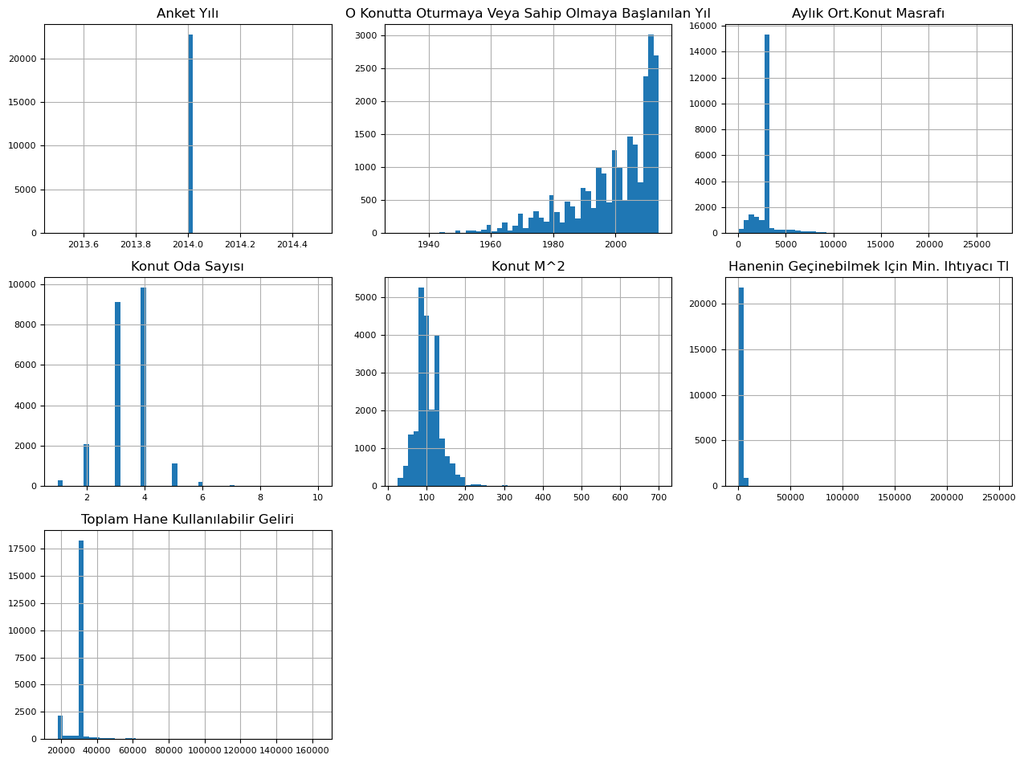

```python
import matplotlib.pyplot as plt
import seaborn as sns
df.hist(bins=50, xlabelsize = 8, ylabelsize = 8)
plt.tight_layout(rect=(0, 0, 2, 2))
```